# Reconsidering the cost of job loss: Evidence from redundancies and mass layoffs

Converted from PDF `Cederlof-JobLossCosts-2024-IFAU.pdf` · 78 pages · anchors: page `#pN`, block `#pN-bK`

Page 1

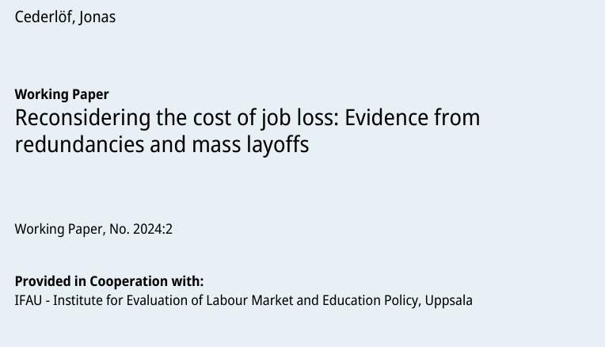

NOTE: figure/graphic rendered as an image from the PDF; its content is not machine-readable text. Caption (if any) follows as the next block.

**text found inside the figure**

Cederlöf, Jonas

**Working Paper** Reconsidering the cost of job loss: Evidence from redundancies and mass layoffs

Working Paper, No. 2024:2

**Provided in Cooperation with:** IFAU - Institute for Evaluation of Labour Market and Education Policy, Uppsala

*Suggested Citation:* Cederlöf, Jonas (2024) : Reconsidering the cost of job loss: Evidence from redundancies and mass layoffs, Working Paper, No. 2024:2, Institute for Evaluation of Labour Market and Education Policy (IFAU), Uppsala

This Version is available at: https://hdl.handle.net/10419/297027

#### **Terms of use:**

*Documents in EconStor may be saved and copied for your personal and scholarly purposes.*

Page 2

**WORKING PAPER 2024:2 Reconsidering the cost of job**

## **loss: Evidence from**

Jonas Cederlöf

Page 3

The Institute for Evaluation of Labour Market and Education Policy (IFAU) is a research institute under the Swedish Ministry of Employment, situated in Uppsala. IFAU’s objective is to promote, support and carry out scientific evaluations. The assignment includes: the effects of labour market and educational policies, studies of the functioning of the labour market and the labour market effects of social insurance policies. IFAU shall also disseminate its results so that they become accessible to different interested parties in Sweden and abroad. Papers published in the Working Paper Series should, according to the IFAU policy, have been discussed at seminars held at IFAU and at least one other academic forum, and have been read by one external and one internal referee. They need not, however, have undergone the standard scrutiny for publication in a scientific journal. The purpose of the Working Paper Series is to provide a factual basis for public policy and the public policy discussion.

More information about IFAU and the institute’s publications can be found on the website www.ifau.se

ISSN 1651-1166

Page 4

### Reconsidering the cost of job loss: Evidence from redundancies

### and mass layoffs*

Jonas Cederl¨of<sup></sup>

#### **Abstract**

This paper studies the consequences of job loss. While previous literature has relied on mass layoffs and plant closures for identification, I exploit discontinuities in the likelihood of displacement generated by a last-in-first-out rule used at layoffs in Sweden. Matching data on individual layoff notifications to administrative records, I find that permanent earnings losses are only found among workers losing their job in mass layoffs, whereas workers displaced in smaller layoffs fully recover. Auxiliary analysis suggests that large layoffs increase exposure to non-employment, prolong unemployment and cause workers to leave the labor force, conceivably by affecting the local labor market.

**JEL:** J63, J64, J65 **Keywords:** last-in-first-out, job loss, displaced worker, mass layoff, earnings loss

*I am deeply indebted to my advisor Peter Fredriksson whose comments have benefited this paper greatly. A special thanks also to David Seim for, in addition to feedback, providing accesses to the data. I also thank Niklas Blomqvist, Ines Helm, Susan N. Houseman, Andreas Kostøl, Marta Lachowska, Alexandre Mas, Arash Nekoei, Johannes Schmieder, Andreas Steinhauer, Johan Vikstr¨om, Mathias von Buxhoeveden, Erik <sup>¨</sup>Oberg, Bj¨orn <sup>¨</sup>Ockert as well as seminar participants at Stockholm University, IFN, UCLS, Uppsala University, 31st EALE Conference, IIES, NHH, University of Bristol, University of Edinburgh, Lule˚a University of Technology, Upjohn Institute for Employment Research, University of Nottingham and Linnaeus University for valuable comments and suggestions. Funding from Handelsbanken, Riksbankens Jubileumsfond (P18-0909:1) and FORTE (2021-01559) is gratefully acknowledged.

IFAU, University of Edinburgh and UCLS. Email: jonas.cederlof@ifau.uu.se

Page 5

### **Contents**

| 1 | Introduction | 1 |
| --- | --- | --- |
| 2 | Institutional setting & data | 6 |
|  | 2 1 Data . . . . . . . . . . . . . . . . . . . . . . . . . . . . . . . . . . . . . . . . . . . . | 7 |
|  | 2 1 1 Descriptive statistics . . . . . . . . . . . . . . . . . . . . . . . . . . . . . . . . | 9 |
| 3 | The LIFO rule and layoff | 10 |
|  | 3 1 Empirical strategy . . . . . . . . . . . . . . . . . . . . . . . . . . . . . . . . . . . . | 10 |
|  | 3 2 Selection around the discontinuity . . . . . . . . . . . . . . . . . . . . . . . . . . . | 11 |
|  | 3 .3 Layoff and the LIFO -threshold . . . . . . . . . . . . . . . . . . . . . . . . . . . . | 13 |
| 4 | Consequences of layoff for workers | 15 |
|  | 4 1 The total earnings effect . . . . . . . . . . . . . . . . . . . . . . . . . . . . . . . . . | 15 |
|  | 4 2 Earnings losses by margins of adjustment . . . . . . . . . . . . . . . . . . . . . . . | 18 |
|  | 4 3 Decomposing the earnings effect . . . . . . . . . . . . . . . . . . . . . . . . . . . . | 19 |
| 5 | Understanding earnings losses upon job loss | 20 |
|  | 5 1 Estimating earnings losses using mass layoff . . . . . . . . . . . . . . . . . . . . . . | 21 |
|  | 5 1 1 Results . . . . . . . . . . . . . . . . . . . . . . . . . . . . . . . . . . . . . . . | 22 |
|  | 5 1 2 Reweighting mass layoff estimates . . . . . . . . . . . . . . . . . . . . . . . . | 23 |
|  | 5 2 Event study vs RD estimator . . . . . . . . . . . . . . . . . . . . . . . . . . . . . . . | 23 |
|  | 5 3 Earnings losses by size of layoff . . . . . . . . . . . . . . . . . . . . . . . . . . . . . | 25 |
| 6 | Sources of permanent earnings losses in mass layoffs | 26 |
|  | 6 .1 The role of non-employment . . . . . . . . . . . . . . . . . . . . . . . . . . . . . . | 27 |
|  | 6 2 The role of local labor markets . . . . . . . . . . . . . . . . . . . . . . . . . . . . . | 28 |
| 7 | Conclusions | 29 |
| References |  | 34 |
| Figures and tables |  | 35 |
| Appendix |  | 49 |
| A | Additional figures and tables | 49 |
| B | Optimal bandwidth | 68 |
| C | Notifications institutions law and data - , | 69 |
| D | Calculation of tenure | 71 |

NOTE: table converted from PDF layout to HTML text; cell boundaries are reconstructed. See PDF if exact alignment matters.

Page 6

### **1 Introduction**

A large body of literature documents that displaced workers suffer significant and even per-

manent losses in terms of their future earnings, wages and employment.<sup>1</sup> What drives these

earnings losses is, however, vividly debated as standard models of the labor market have trouble

generating both the magnitude and the persistence of empirically observed losses (Davis and

von Wachter, 2011) or disagree upon its sources (Carrington and Fallick, 2017). Meanwhile,

understanding why and under what circumstances the costs of job loss are most persistent is

of great importance not only for our theoretical understanding of the labor market but also for

public policy.

Since the seminal study by Jacobson, Lalonde and Sullivan (1993) the vast majority of re-

search estimating the consequences of job loss compare displaced *vis-`a-vis* non-displaced work-

ers, across firms, using mass layoff and plant closure as an exogenous source of variation.<sup>2</sup>

However, such events are quite extraordinary as most job loss occur due to less drastic and

more marginal adjustments to employment. In fact, only about 8 percent of all involuntary

separations in the US between 2003–2012 occurred during mass layoffs.<sup>3</sup> Unfortunately, evi-

dence from the remaining 92 percent of smaller layoffs are conspicuously absent, and little is

known how previous findings generalize beyond mass layoffs or to what extent such extraordi-

nary events render extraordinary consequences. This paper aims to fill this gap by providing

the first empirical evidence showing how the size of layoff influence earnings losses upon job

loss and how it is imperative for our understanding of the standard result of permanent losses

among displaced workers.<sup>4</sup>

The key challenge in obtaining credible estimates of earnings losses following job loss is

that displacement is a non-random event. For instance, it is widely recognized that displaced

workers may be adversely selected (see e.g. Gibbons and Katz, 1991; Pfann and Hamermesh,

1For example, see Davis and von Wachter (2011); Eliason and Storrie (2006); Hijzen, Upward and Wright (2010); Jacobson, Lalonde and Sullivan (1993); Lachowska, Mas and Woodbury (2020); Ruhm (1991); Song and von Wachter (2014); Schmieder, von Wachter and Heining (2023); Burdett, Carrillo-Tudela and Coles (2020); Athey, Simon, Skans, Vikstrom and Yakymovych (2023). Reviews of the literature can be found in Couch and Placzek (2010); Davis and von Wachter (2011); Fallick (1996). Displacement has also been shown to lead to worse health (see e.g. Black, Devereux and Salvanes, 2015; Browning, Dano and Heinesen, 2006; Jolly and Phelan, 2017; Kuhn, Lalive and Zweim¨uller, 2009; Schaller and Stevens, 2015), increased mortality (Eliason and Storrie, 2009; Sullivan and von Wachter, 2009), lower fertility (Huttunen and Kellokumpu, 2016), negatively affecting children of displaced workers (Rege, Telle and Votruba, 2011; Stevens and Schaller, 2011) and increasing the probability of committing crime (Britto et al., 2022; Bennett and Ouazad, 2019).

2Two exceptions are Stevens (1997) and Kletzer and Fairlie (2003) who, by relying on survey data, also include smaller layoffs in their analysis. However, neither study performs a separate analysis for small *vis-a-vis* large layoffs.

3Calculations are based upon data from the Bureau of Labor Statistics by combining data from the Mass Layoff Statistics program (which ended in March 2013) with the Job Openings and Labor Turnover Survey (JOLTS) reporting the total number of layoffs and discharges which is made up of all involuntary separations initiated by the employer. Both these data sources can be accessed at http://www.bls.gov.

4An interesting, although somewhat overlooked, fact is that Jacobson, Lalonde and Sullivan (1993) already in their study, in one specification, studied earnings of workers laid off in non-mass layoffs (i.e smaller layoffs) and found that “[...] following separation they drop by only one-half as much as workers in the mass-layoff sample” (p. 699). Moreover, these losses were transitory as workers fully recovered within 3-5 years. However, the finding was primarily attributed to the non-mass layoff sample including “[...] larger fractions of workers who quit their jobs [...]” (p. 699), and thus considered to be a non-representative estimate for involuntarily displaced workers.

1

Page 7

2001; Lengerman and Vilhuber, 2002; von Wachter and Bender, 2006; Couch and Placzek, 2010;

Davis and von Wachter, 2011; Schwerdt, 2011; Jung and Kuhn, 2018). That is, if employers

are able to select which workers to lay off, whereas others may leave the firm early in an-

ticipation of future downsizing, displaced workers may be of lower quality and have *ex ante*

lower earnings trajectories. One additional difficulty lies in distinguishing between voluntary

and involuntary separations in data, where mistaking the former for the latter may understate

workers’ true earnings losses.<sup>5</sup> To overcome these challenges, the literature has typically relied

on estimating distributed lag models with individual fixed effects; comparing earnings trajec-

tories of high tenured (often male) workers displaced during mass layoffs or plant closures to

those of non-displaced observationally equivalent workers at non-downsizing firms. While the

empirical strategy may solve the selection problem, estimates will by design pertain to a partic-

ular population of workers laid off under rather specific circumstances.<sup>6</sup> Also, to the extent that

low productivity firms attract low productivity workers (Abowd, Kramarz and Margolis, 1999)

and inference is based on high tenured workers, estimates may reflect the effect for displaced

workers with less favorable characteristics or a particularly good match (Lachowska, Mas and

Woodbury, 2020).

This paper takes a novel approach to estimating the consequences of job loss on subsequent

labor market outcomes by exploiting the use of a seniority rule used at layoffs in Sweden, namely

the last-in-first-out (LIFO) rule. The LIFO rule is written into Swedish labor law and mandates

that workers within the same establishment, performing similar tasks and being part of the same

collective bargain agreement (CBA), should be laid off in inverse order of seniority, whereby

more recent hires ought to be let go before workers with higher tenure. Using detailed matched

employer-employee data, containing information on job start and end dates, I rank workers

according to their relative seniority (tenure) within an establishment which, by the LIFO rule,

renders variation in the probability of displacement. Combining these data with wage registers

and a unique individual register dataset containing all layoff notifications involving at least 5

workers during 2005–2015, I identify occupation specific cut-offs in downsizing establishments

where the probability of displacement jumps discontinuously. This generates quasi-experimental

variation which lends itself to a (fuzzy) regression discontinuity (RD) design. The key threat to

a causal interpretation of these estimates is that firms selectively displace workers by choosing

not who, but rather, how many workers to lay off. Although such manipulation is unlikely

due to priority of recall for the last displaced worker, I carefully address this concern through

a series of tests and find no evidence of selective firing based on observable pre-determined

characteristics or earnings prior to the displacement event.<sup>7</sup>

5As pointed out by Couch and Placzek (2010), one additional justification for looking only at workers separating during a mass layoff is to avoid including people fired for cause, which would likely overstate true earnings losses. Likewise, earnings losses may also be exaggerated by including quits if these are predominantly induced by workers’ choosing non-employment due to e.g. discouragement or poor health.

6Previous research has shown that firms executing mass layoffs tend to be concentrated to particular industries with overall higher turnover rates (Fallick, 1996; Krashinsky, 2002; von Wachter and Bender, 2006; Sullivan and von Wachter, 2009)

7To the extent that there are imbalances in unobserved worker productivity due to employers being able to

2

Page 8

Leveraging the discontinuities implied by the LIFO rule, I find that displaced workers have

about 40 percent lower earnings compared to their non-displaced coworkers, one to two years

after layoff notification. The size of these initial losses are similar in magnitude to what has been

observed in the US (cf. Jacobson, Lalonde and Sullivan, 1993; Sullivan and von Wachter, 2009;

Lachowska, Mas and Woodbury, 2020) as well as in Europe (cf. Schmieder et al., 2023; Burdett

et al., 2020; Bertheau et al., 2022). However, as time goes by, the earnings gap between displaced

and non-displaced workers shrink and is fully closed 7 years after displacement. Importantly,

the closing of the gap is not driven by recalls or initially non-displaced workers getting laid

off at a later point in time, but from displaced workers climbing back up the job ladder. I

decompose the earnings losses into different margins of adjustment; wages, employment and

hours worked. While employment differences account for the lion share of the initial difference

in earnings, these have subsided after 3 years. Displaced workers suffer wage cuts at their new

jobs but have faster wage growth than their non-displaced former colleagues and after 7 years

earn the same wage. Hours responses are small and insignificant throughout the recovery.

As the finding of earnings losses being transitory, rather than persistent, stands in stark

contrast to the standard result in the literature (see Table A.1 for a summary of estimates), I

probe this result in great detail. I begin by estimating earnings losses using the conventional

event study mass layoff estimator. Here I find large and permanent earnings losses ranging

between 14 to 21 percent 10 years after displacement, thus ruling out that the transitory pattern

observed in the RD analysis is context or time specific. Further, to ensure that these results

are not driven by compositional differences across the two samples, I reweight the estimates to

mimic the LIFO sample in multiple dimensions. While rendering a slight decrease in long-run

losses, they remain permanent and substantial 10 years after layoff, suggesting that differences

in e.g. worker composition, industry composition, firm size or time of layoff cannot explain the

transitory pattern found in the RD analysis.

One key difference between the canonical mass layoff estimator and the RD is that the for-

mer exploits variation across firms and the latter within firms, thus rendering results from two

potentially different experiments with different contra factual states. Moreover, whereas the tra-

ditional estimator identifies the effect for the average displaced worker, the RD analysis pertains

to the marginally displaced worker. To account for these differences, I combine the two esti-

mators by matching workers below the LIFO-threshold to workers in other (non-downsizing)

establishments, emulating the conventional control group used in the literature. Estimating

earnings losses at the threshold using variation across establishments renders slightly larger

earnings losses on average, but nevertheless continue to be transitory with workers fully recov-

ering within 10 years. These results, however, conceal a great deal of heterogeneity, as splitting

the sample by size of layoff reveals that permanent earnings losses are present, but only among

workers displaced in large layoffs while workers displaced in smaller layoffs recover much faster,

selectively displace workers, estimates should be downward biased rendering earnings losses to be exaggerated. Nevertheless, in light of the finding that earnings losses are transitory rather then persistent, this would suggest that in absence of selection, displaced workers recover even faster.

3

Page 9

closing the earnings gap 6–7 years after displacement. The pattern is also confirmed when split-

ting layoffs by size using the original (non-matched) sample where a clear negative correlation

between long-run earnings losses and the size of layoff is visible, even after reweighting larger

layoffs to resemble small layoffs in multiple dimensions.

Altogether, these findings suggest that mass layoffs are very different from less drastic and

more common redundancies in that they generate not only larger but also permanent earnings

losses; a fact which cannot be accounted for by estimation technique nor differences in industry

or worker composition, or economic conditions at the time of layoff. This result is, to the best of

my knowledge, new to the literature on worker displacement and suggests that, although being

a serious concern, permanent worker scarring is not as ubiquitous a phenomenon as previous

research may have lead one to believe.<sup>8</sup> This result also has important implications for public

policy, suggesting that focus and resources should be geared towards workers displaced in large

layoffs.

In the last part of the paper, I explore why large layoffs – in contrast to smaller redundancies

– have permanent effects on workers’ earnings. Several recent studies have set out provide

explanations for why displacement during mass layoff render permanent losses. For example,

Schmieder, von Wachter and Heining (2023) have emphasized the loss of establishment specific

wage premiums, while Krolikowski (2017) and Lachowska, Mas and Woodbury (2020) highlight

the loss of a match specific component. Others point to the role of aggregate labor market

conditions as an important determinant for earnings losses (Davis and von Wachter, 2011;

Schmieder, von Wachter and Heining, 2023; Huckfeldt, 2022) and that longer unemployment

duration may lead to the loss of human capital and lower reemployment wages (Schmieder, von

Wachter and Bender, 2016; Burdett, Carrillo-Tudela and Coles, 2020; Jarosch, 2023).

I show that workers displaced in large layoffs (in comparison to smaller ones) have more

exposure to non-employment, higher probability of (long-term) unemployment, as well as leaving

the labor force altogether. Moreover, having been part of a large layoff, workers are more likely

to find work outside their local labor market, compared to if the layoff was small. As these

effects are again robust to accounting for differences in worker and industry compositions across

layoff size, as well as overall economic conditions at layoff, I consider the possibility of large

layoffs affecting the entire local labor market through e.g. labor congestion. To this end, I first

note that large layoff are typically large also in relation to the local industry labor market. As

such, I study hetrogenity in the impact of layoff size by the local importance of a particular

8These results contrast one auxiliary finding in Flaaen, Shapiro and Sorkin (2019) who combine administrative data with individual level data from the Survey of Income and Program Participation (SIPP). They find that “[...] conditional on the survey reason for separation, the differences in earnings loss estimates between firms that are contracting and firms that are stable are small” (p.215). A potential concern, however, is that their identification strategy cannot – in contrast to the LIFO-rule – account for adverse selection of workers in smaller layoffs, which may render their estimates downward biased. In addition, for this auxiliary analysis Flaaen, Shapiro and Sorkin (2019) exclude observations with zero earnings, but show for the main analysis that the inclusion of zero earnings generates almost three times larger long-run losses. As I show in section 6, a key difference between small and large layoffs is that the latter renders longer unemployment and induce more workers to leave the labor force, making the inclusion of zero earnings observations vital for studying the differential impact of small *vis-`a-vis* large layoffs.

4

Page 10

industry, finding that earnings losses are only permanent among workers displaced in large

layoffs where the downsizing firms’ industry also make up a large share of total employment in

the local labor market.

Relative to the previous literature estimating earnings losses upon displacement, this is the

first paper to exploit a seniority rule as an exogenous source of variation to involuntary job

loss. In doing so, I am able to provide first time, and until now strikingly absent, evidence on

the consequences of job loss not due to mass layoff or plant closure, absent of adverse selection

of workers. The paper adds new and important insights to the literature on displaced workers

by showing that the size of layoff is an imperative determinant to understanding persistent

earnings losses.<sup>9</sup> The findings also speak to a recent part of the literature seeking to understand

what drives earnings losses to become permanent. Both the empirically oriented part (see

e.g. Lachowska et al., 2020; Schmieder et al., 2023; Athey et al., 2023), as well as the more

theoretically oriented one (see e.g. Krolikowski, 2017; Jung and Kuhn, 2018; Burdett, Carrillo-

Tudela and Coles, 2020; Huckfeldt, 2022; Jarosch, 2023) where the persistence in earnings losses

often have eluded standard models of the labor market (Davis and von Wachter, 2011). I see

my findings to be much in line with Gathmann et al. (2018) showing how firms in the same

industry as a mass layoff plant suffer from negative spillovers, and Gulyas and Pytka (2020)

documenting that displacement firm wage premia and the availability of jobs in a local labor

market are key factors in explaining post displacement outcomes. Finally, my findings are

also congruent with the recent literature showing how displacement renders longer and serially

correlated unemployment spells where workers lose human capital (see Burdett, Carrillo-Tudela

and Coles, 2020; Jarosch, 2023).

The rest of the paper unfolds as follows. Section 2 provides a brief description of the overall

usage of seniority rules at layoff and gives a more detailed description of the Swedish LIFO

principle that is used for identification. I also describe the data and define the relevant variables

used to identify workers’ relative seniority within an establishment. The empirical strategy is

laid out in Section 3, together with a discussion and multiple tests of the identifying assumptions

needed for causal inference. The section ends with examining the empirical relationship between

workers’ relative seniority and layoff, i.e. the first stage. Section 4 presents the results on workers

subsequent labor market outcomes and decomposes the overall earnings effect into various

margins of adjustment. In Section 5, I seek to understand when and why, following displacement,

permanent earnings losses are present. Section 6 examines why permanent earnings losses are

primarily found among workers displaced in large layoffs. Section 7 concludes.

9In a recent paper, Fackler et al. (2021) exploit bankruptcies (firm closures) in Germany during the Great Recession, to study the importance of firm size on workers’ earnings and wages after job loss. They show that workers displaced from small firms (*<* 10 employees) tend to have smaller earnings losses compared to workers displaced in large firms (*≥*100 employees) (roughly 7 percent vis-a-vis 11 percent, 5 years after dispalcement; see Online Appendix Figure G.1 of Fackler et al., 2021). Importantly, however, one should not conflate firm size and layoff size. While these are synonymous in the particular case of bankruptcies, large layoffs are generally, and almost mechanically, more frequent among small firms and vice versa, as layoff size is defined as the number of displaced workers divided by the number of employed. The empirical correlation between firm and layoff size in my main sample is *ρ* = *−*0*.*383 and the average establishment in my main sample has 169 employees (see Table 1).

5

Page 11

### **2 Institutional setting & data**

The LIFO rule is a type of seniority rule which mandates that more recent hires should be dis-

placed before workers with longer tenure. Thus a workers’ relative tenure ranking is predictive,

albeit not perfectly, of displacement in the event of an establishment downsizing. Seniority rules

are part of the broader concept of employment protection as it provides insurance and protects

tenured workers against unjust termination (Pissarides, 2001). While being largely beneficial

for the incumbent worker, high employment protection is generally thought to increase firms

firing costs which in turn may hamper job creation and generate inefficiently low labor turnover

(see e.g. Lazear, 1990; Mortensen and Pissarides, 1994).

Seniority rules are used at layoff in many countries (e.g., Germany, UK, Netherlands, and

others) although with considerable differences across sectors and countries. Buhai et al. (2014)

empirically documents the use of seniority rankings in layoff decisions in Denmark and Portu-

gal, although it is unclear whether any formal rules are the cause of these findings. Lee (2004)

documents the use of seniority rules in the United States and notes that in e.g. 1995 about 88

percent of all union contracts contained at least some seniority provision for layoff decisions. For

Sweden, B¨ockerman, Skedinger and Uusitalo (2018) and Landais et al. (2021) documents em-

pirical patterns consistent with the use of a seniority rule, which together with the Netherlands,

is one of few countries who explicitly refer to a seniority rule in the Employment Protection Act

as the main criteria for prioritizing among workers in the event of downsizing. However, none

of the aforementioned papers have been able to pin down the use of a strict seniority rule (e.g.,

a LIFO rule) by establishing discontinuities in seniority ranking.

**The Swedish LIFO rule** The Swedish Employment Protection Act (EPA:22§) stipulates

that when a firm needs to downsize due to “shortage of work” it should follow a LIFO principle

which mandates that workers should be laid off in inverse order of seniority.<sup>10</sup> In the event

of a tie in tenure, priority should be given to the older worker. Formally, the LIFO rule

applies at the establishment level. In the event of multiple layoffs, employers should divide

workers into groups based on workers CBA affiliation and list workers according to the length

of employment.<sup>11</sup> These groups form so called order of termination circuits (*turordningskrets*)

(henceforth refereed to as an order circuit or circuit, for short). Importantly, labor law also

stipulates a “last-out-first-in” principle (EPA:26§) where the displaced worker with the highest

tenure within the circuit has priority of recall if the firm needs to start hiring within 9 months

of the displacement. Priority of recall applies to workers with at least 12 months of tenure,

who is deemed sufficiently qualified for the new job and had expressed a wish for recall to the

employer prior to layoff.

10The term “shortage of work” can be somewhat misleading as legal practice has come to interpret this as all layoffs not related to personal behavior of an individual worker.

11Whereas the LIFO rule applies at the establishment level, a workers’ tenure – on which he is ranked upon – is based on total time at the firm, irrespective of whether the worker has worked sporadically, part-time or full-time. During e.g. firm acquisitions or mergers tenure is not reset but the start date of employment is that of the initial employer.

6

Page 12

Some parts of Swedish labor law consists of semi optional paragraphs, meaning that these

could be bypassed by employee and employer organizations through CBA’s or local agree-

ments.<sup>12</sup> One such paragraph is the LIFO rule. An employer may deviate from the LIFO

principle by agreeing on a different order of priority with local union representatives in a ne-

gotiation. However, if the employer and the union are unable to strike a deal, the LIFO rule

as written in law should be applied. As such, the Swedish LIFO rule functions as a default or

starting point for negotiations between the local union and the employer. Unfortunately, little

is known about how frequently agreements of deviations from the LIFO principle are made in

practice.<sup>13</sup> Hence, it is ambiguous whether employer compliance with the LIFO principle at

layoff is voluntary or invoked by the local union. Finally, firms with less than 10 employees are

allowed to exempt two workers that are of particular importance for the firm. Also, workers in

managerial positions or part of the employers’ family may be exempted from the LIFO rule.

#### **2.1 Data**

In a first stage, the firm reports to the PES the number of intended layoffs and the reason for

downsizing. In a second stage, occurring on average 70 days after the first, the firm submits a

list of names of the workers affected by the displacement. This list should be sent in at least one

month before the first worker being laid off. Typically, all workers are notified on the same date

whereas the date of displacement differs due to differences in statutory notification times.<sup>14</sup>

This implies that all workers, irrespective of their seniority, are made aware of the impending

layoff at the same time.

These data are then matched with a data set containing the universe of employer-employee

matches between 1985 to 2018, which contains information on both firm and individual charac-

teristics such as age, level of education and annual earnings. The data is annual, and along with

the annual income statement, the employer reports the first and last month worked for each

employee. These monthly markers make it possible to calculate firm specific tenure as well as

determine the current workforce within an establishment in any given month. One issue with

the monthly markers is that employers sometimes routinely report workers as having worked

the entire year so that January is too often reported as being the start of the employment

12CBA’s are industry or occupation specific and covers all employees (also non union members) at firms who has signed such an agreement. There are separate CBA’s for white- and blue-collar workers and about 90 percent of the Swedish workforce is covered by a CBA whereas the union membership rate has declined from 81 to 69 percent between 2000–2020 (Kjellberg, 2019).

13Deviations from the LIFO principle should, however, not contravene “good practice in the labor market” or violate the Discrimination Act (EPA:22§).

14Workers that are laid off due to no-fault individual dismissals are entitled to advance notice where the length of the notice period varies (discontinuously) with tenure by law and at times by age according to local CBA’s. Appendix C describes the notification process and law in more detail and provides some descriptive statistics (see also Cederl¨of et al., 2021). The tenure thresholds that govern notification times, may occasionally line up with the LIFO-threshold. Note, however, that this does not affect identification at the LIFO threshold as it is based on the comparison between displaced and non-displaced workers. Nevertheless, empirically the jump at the threshold among notified workers just above and below as estimated to 0.296 days (*SE* = 2*.*179).

7

Page 13

spell which may in turn generate measurement error in tenure. Moreover, a common feature of

matched employer-employee data are so called false firm deaths where firms for other reasons

than shut-down change identification number. Such occurrences would lead to erroneously re-

setting workers tenure, thereby creating large amount of inaccurate ties in tenure within a firm.

As these data shortcomings in measuring tenure will map directly onto the running variable I

try to minimize its influence by dividing workers starting in January into quartiles of annual

earnings in the first year of employment where lower quartiles are assumed to have started

employment later. I also exclude circuits where more than 2/3 of workers have tenure equal to

the mode of tenure within the circuit.<sup>15</sup> In Appendix D, I explain in detail the procedure for

calculating tenure and elaborate on the sources of measurement error relevant for the running

variable.

As described in Section 2, the LIFO rule applies at the establishment*×*CBA level. Ideally,

one would like to have accesses to which workers are covered by which CBA. As these data

do not exist, I proxy CBA affiliation using (the Swedish version of) 2-digit level ISCO-88

(International Standard Classification of Occupations 1988) occupational codes provided in the

wage register collected by Statistics Sweden each year. The register also contain information

on (full-time equivalent) wages and is available for a large sample of establishments, covering

almost 50 percent of all private sector workers and all public sector workers from 2000 to 2018.

The sampling of private sector workers is done by firm (stratified by size) which again enables

me to classify occupation for the entire workforce at each (sampled) establishment.<sup>16</sup>

Through these data, I determine the order of termination implied by the LIFO rule, for all

establishments having sent a layoff notification to the PES and for which I have data on workers’

occupation. Within circuits, I rank individuals according to seniority, adapting the convention

of 1 being the highest tenured worker. Individual *i*’s relative ranking within an order circuit *c*

could then be written as

*RRic* = *SRic −*(max

**equation / math rendering (image)**

NOTE: contains mathematical notation; text above is the PDF text layer and symbols may be mis-extracted. Image shows the original.

**equation / math rendering (image)**

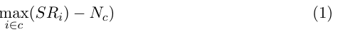

NOTE: contains mathematical notation; text above is the PDF text layer and symbols may be mis-extracted. Image shows the original.

where *SRic* is the seniority ranking and *Nc* is the number of notified workers reported in the

list submitted by the employer to the PES.<sup>17</sup> *RRic* is the running variable defining the relative

tenure ranking normalized to zero for the worker who, by the LIFO rule, should be the last

worker to remain employed. Figure 1 illustrates *RR* for two occupations (pink and gray) within

a downsizing establishment in a given year. These form two separate circuits where workers

15An alternative approach, suggested by Hethey-Maier and Schmieder (2013), is to correct false firm/establishment deaths using worker flows. This involves categorizing last appearances of establishment identifiers as closures, mergers, spin-offs, etcetera, by placing restrictions on observed worker flows. As this approach requires more than one, possibly arbitrary, restrictions I find that placing only one restriction is more transparent.

16The survey is carried out in September and November and thus, strictly speaking, information on the composition of the workforce, occupation and wages corresponds to these months. This implies that order circuits should be better approximated for notifications that occur around September and November. Indeed, the precision of the first stage is much better for notifications made in the month of September to January than other months.

17I use the number of notified workers provided in the second stage of the reporting process. The reason is that firms have an incentive to over report the initial number of intended layoffs as they are prohibited from going beyond this number when finalizing the list of workers getting displaced.

8

Page 14

are ranked according to tenure (and age in case of a tie). In the upper row *Nc* = 3 and the

lower *Nc* = 2. Thus, workers to the right of the cut-off (with *RR >* 0) would get displaced if

the establishment fully applied the LIFO rule. Note that the number of notified workers (*Nc*)

is set endogenously by the firm. This may be problematic if firms select *Nc* based on worker

characteristics as it would cause selective firing. I address this concern thoroughly in Section

3.2.

I have imposed some further restrictions on the data. First, I exclude layoff notifications

where plant closures and bankruptcies are reported as the cause of displacement, as the threshold

within circuits in such establishments are undefined since everyone is laid off. I also discard no-

tifications due to an establishment moving as it may be endogenous whether the worker chooses

to reallocate with the establishment. Second, I restrict the analysis to industries dominated

by blue-collar workers as the LIFO rule to a greater extent applies among blue-collar workers.

From this restriction it also follows that almost all establishments operate in the private sector.

Finally, I condition on layoff notifications affecting at least 10 workers within an order circuit

which is restricted to contain at most 100 workers.<sup>18</sup>

#### **2.1.1 Descriptive statistics**

Table 1 presents descriptive statistics for the main analysis (LIFO) sample along with two

relevant comparison groups. For reference, column (1) shows average characteristics for all

workers reported to the PES as being notified of their displacement. These workers are on

average 40 years old and have about four and a half year of tenure at the displacing firm. Little

more than one third of the sample are female and only 12 percent have a college degree likely

reflecting the fact that one third of all notified workers come from the manufacturing industry.

Compared to the average notified worker, workers in the LIFO sample (column 2) are about

2 years younger, have about 2 years longer tenure, and are somewhat less educated. Note

that column (2), as opposed to column (1), have both notified/displaced and non-notified/non-

displaced workers. Due to restricting the analysis to blue-collar dominated sectors, workers

from manufacturing firms are heavily overrepresented.<sup>19</sup>

To facilitate comparison with previous literature, I define a typical mass layoff sample whose

characteristics can be seen in column 3 of Table 1. How this sample is constructed is detailed

in Section 5.1, but, broadly I follow Schmieder et al. (2023) and Lachowska et al. (2020) and

focus on workers with at least 5 years of tenure who are displaced along with at least 30 percent

of the workforce at an establishment (i.e in a mass layoff) with at least 50 workers. Again,

18The lack of a one-to-one mapping between CBA’s and occupation codes makes it difficult to precisely define the relevant workforce subject to the notification. Thus, the full tenure distribution within the order circuit may be obscured by erroneously including workers in an order circuit which they do not belong to. Misallocating just one worker will render the circuit too large or too small, thereby leading me to place the discontinuity in the wrong place in the tenure distribution. Thus placing restrictions on the maximum size of the order circuit increases precision of the first stage as the probability of including the “wrong” workers decreases.

19As the identifying variation comes from the compliers just at the threshold Table A.2 characterizes the complier population following Abadie et al. (2002). The overall estimation sample is very similar to the complier population.

9

Page 15

workers are primarily concentrated in the manufacturing industry and as a consequences of the

imposed standard restrictions workers in the mass layoff sample have about twice the tenure

as the average notified worker but only about 4 percent higher earnings. Firms are on average

larger in the mass layoff sample, however, establishments are about the same size.

### **3 The LIFO rule and layoff**

#### **3.1 Empirical strategy**

As seniority within an establishment will be positively correlated with worker ability and pro-

ductivity, correlating workers relative ranking with future earnings will inevitably be biased due

to omitted variables. Similarly, a mere comparison of displaced *vis-`a-vis* non-displaced workers

will render biased estimates as firms could selectively displace workers with an ex ante lower

earnings trajectory (due to e.g. low productivity). The LIFO rule, however, imposes restric-

tions on the employer in choosing between two workers working at the same establishment who

performs similar tasks.

Following the definition of relative ranking (*RR*) in equation (1), I define the instrument as

*Zic* = **1**[*RRic >* 0] where **1**[*·*] is the indicator function. Further, I define a control function for

relative ranking

*h*(*RRic*) = [*h*0(*RRic*) + *h*1(**1**[*RRic >* 0] *× RRic*)] (2)

**equation / math rendering (image)**

NOTE: contains mathematical notation; text above is the PDF text layer and symbols may be mis-extracted. Image shows the original.

which allows for different slopes on each side of the threshold. Since tenure is discrete and

measured in months, I rely on a parametric control function varying the functional form in

contrast to more non-parametric estimation techniques suggested by Calonico et al. (2014).

The first stage equation can then be written as

*Dic* = *α* + *γZic* + *h*(*RRic*) + *ϕc* + *ρX<sup>′</sup>*

**equation / math rendering (image)**

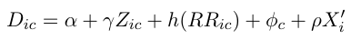

NOTE: contains mathematical notation; text above is the PDF text layer and symbols may be mis-extracted. Image shows the original.

**equation / math rendering (image)**

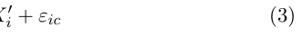

NOTE: contains mathematical notation; text above is the PDF text layer and symbols may be mis-extracted. Image shows the original.

where *γ* is the first stage effect on the probability of being displaced (*Dic*). *X<sup>′</sup>*

pre-determined baseline covariates included to increase efficiency and *εic* an error-term.<sup>20</sup> *ϕc* is an order circuit fixed effect which consists of unique combinations of a firm, establishment,

occupation and notification year fixed effects. The corresponding outcome equation is

*yict* = *π* + *βDic* + *h*(*RRic*) + *ϕc* + *δX<sup>′</sup>*

**equation / math rendering (image)**

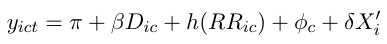

NOTE: contains mathematical notation; text above is the PDF text layer and symbols may be mis-extracted. Image shows the original.

*i* <sup>+</sup>*<sup>u</sup><sup>ict</sup><sup>.</sup>* (4)

**equation / math rendering (image)**

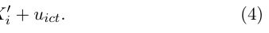

NOTE: contains mathematical notation; text above is the PDF text layer and symbols may be mis-extracted. Image shows the original.

Substituting equation (3) into (4) yields the reduced form equation. As order circuits are prox-

ied and the LIFO rule semi optional, assignment to displacement will not be a fully deterministic

function of a workers relative ranking (i.e., *γ <* 1). Hence, in order to estimate the cost of dis-

placement, I instrument *Dic* with *Zic*, rendering a fuzzy RD-design. The resulting instrumental

variable (IV) estimate may then be interpreted as the local average treatment effect (LATE)

20The included covariates are: age, age squared, gender, immigrant status, educational attainment FE:s.

10

Page 16

for workers just at the margin of lay off within establishments complying with the LIFO rule.

Excludability of the instrument hinges upon the assumption that being just above the (prox-

ied) threshold only affects subsequent labor market outcomes through displacement. While

exclusion is an assumption, it is useful to note that there are no other formal rules pertaining

to the LIFO threshold. Also, the reduced form coefficient is interpretable as the average effect

of being exposed to a higher risk of displacement in the event of downsizing.

In the main specification I use a bandwidth of *±*16 which is the preferred bandwidth using

Calonico et al. (2014) optimal bandwidth selector.<sup>21</sup> I also confirm the robustness of the results

by varying both the bandwidth and the functional form of *h*(*·*) as suggested by Lee and Lemieux

(2010). In all regressions, I use a uniform kernel and cluster the standard errors at the order

circuit level.

#### **3.2 Selection around the discontinuity**

The empirical strategy relies on the assumption of non-manipulation of the running variable.

Specifically, this implies that neither workers nor firms should be able to perfectly manipu-

late who gets notified and eventually displaced, as this could create non-random selection into

displacement which would invalidate the RD research design.

From the perspective of the worker, selective sorting around the threshold is unlikely but

could arise if some workers are more prone than others to leave the establishment before the

notification occurs (cf. Lengerman and Vilhuber, 2002; Schwerdt, 2011).<sup>22</sup> However, in order for

this to amount into imbalances around the threshold, it would require that *i*) workers have pre-

knowledge about the impending notification, *ii*) are aware of their *exact* position in the seniority

ranking and that *iii*) workers just above the threshold, to a greater extent than workers just

below, sort out of the establishment based on characteristics directly affecting the outcome.

A more plausible type of manipulation is one in which the firm chooses whom to displace

by either endogenously forming, i.e manipulating, the order circuits, or by choosing the number

of workers to lay off. The first issue is resolved by proxying order circuits with combinations

of establishment and occupation. This avoids potential manipulation of order circuits as the

proxy functions as an instrument, only picking up establishment/occupation combinations that

adhere to the LIFO rule. If the relative tenure ranking within the establishment/occupation

combination were not predictive of actual order circuits, due to, e.g., deviations agreed upon

between local union representatives and the employer, the first stage coefficient would be zero.

The second potential source of firm manipulation could however be of concern, as firms do set

the cut-off endogenously by choosing how many workers to notify and eventually displace. A

21The optimal bandwidth is based on the main outcome of annual earnings at time of notification. In order to avoid using different samples for each single point estimate, I maintain the same bandwidth for all time horizons. However, as can be seen in Appendix B, the results remain virtually unchanged when using the proposed optimal bandwidth for each time period, separately.

22Note that I exploit variation within order circuits (establishment*×*occupation*×*year combinations) and that all workers employed within the circuit at the time of notification are included in the sample. Thus, any selection around the threshold have to occur prior to notification. Consequently, any differential mobility across the threshold e.g. in between notification and actual displacement is a result of the treatment.

11

Page 17

firm that intends to lay off *n* workers, but realizes that worker *n* + 1 in the seniority ranking

has lower productivity, can instead decide to notify and lay off *n* + 1 workers.

Formally, the identifying assumption that is needed for causal inference can be stated as

**equation / math rendering (image)**

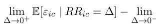

NOTE: contains mathematical notation; text above is the PDF text layer and symbols may be mis-extracted. Image shows the original.

**equation / math rendering (image)**

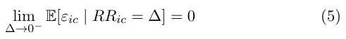

NOTE: contains mathematical notation; text above is the PDF text layer and symbols may be mis-extracted. Image shows the original.

meaning that the distribution of unobserved worker characteristics be continuous at the thresh-

old. Although the continuity assumption cannot be fully tested, its validity is usually be assessed

by checking balance of average worker characteristics just around the threshold.<sup>23</sup>

First, Figure A.1 plots predicted annual earnings estimated by taking the fitted values from

a regression of annual earnings on age, tenure and dummies for female, immigrant and level

of education. Whereas the overall downward trend in predicted earnings stems from workers

with higher relative ranking having lower tenure, there is no indication of selection around the

discontinuity as the estimated jump at the threshold is less than 104 SEK (approximately 10.5

USD) and statistically insignificant. Thus predicted annual earnings evolves smoothly around

the threshold.

Next, in an additional test of the continuity assumption, column (1)–(3) in Table 2 show

estimates from regressing the instrument *Zi* on a set of pre-determined covariates and the control

function *h*(*RRi*). Irrespective of the choice of functional form, or the exclusion of circuit FE’s,

none of the individual variables are predictive of treatment status as coefficients are typically

small as well as statistically indistinguishable from zero. Testing for joint significance using a *F*-

test, I am also unable to reject all coefficients being jointly zero, as can be seen in the bottom of

Table 2. Columns (4) and (5) show results from separate regressions for each baseline covariate,

regressed on the instrument and a first and second order polynomial function, respectively. The

point estimate in column (4) suggest that the difference in annual earnings between workers

just to the right and left of the threshold is less than -0.04% and insignificant. Figure A.4 show

graphically the bivariate balancing tests corresponding to column (4) and (5) as well as for

monthly wages which I have access to for a smaller sample of workers.

Taken together, the fact that observable characteristics and earnings are neither jointly

nor individually predictive of treatment speaks strongly in favor of the continuity assumption.

It suggests that workers just around the threshold are not differentially leaving before noti-

fication, and that employers are unable or unwilling to adjust the number of workers being

notified/displaced such that selective displacement occurs. Arguably, the incentives for laying

off *n* + 1 workers are also small as the marginal worker being laid off have first priority of recall

23It is also customary to examine the density around the threshold to see whether people have selected into treatment. However, as the threshold here is defined by where in the seniority distribution the last worker is notified, standard density tests as suggested by McCrary (2008) are no longer valid as the density around the threshold is balanced almost by construction (I say *almost* due to the fact that I allow for ties in relative ranking if both tenure and age at notification are the same for workers within the same order circuit). For completeness, Figure A.2 in the Appendix shows the density around the threshold. Due to having restricted the sample to at least 10 workers getting notified within a circuit the frequency of observations are about the same up until *RRic >* 10 where it starts to drop.

12

Page 18

up to 9 months after displacement. In sum, I find no evidence of worker sorting or firms setting

the cut-off endogenously such that it would invalidate the RD-design.

The one caveat is that as the number of notified workers is set endogenously by the employer,

imbalances may still exist on *unobservable* worker characteristics. While this, per definition,

cannot be tested, selective displacement of low productivity workers would imply that my

estimates of earnings losses and its persistence are exaggerated. However, in light of the finding

that earnings losses are transitory rather then persistent, this would imply that, in absence of

any bias, displaced workers have in fact smaller earnings losses and recover even faster.

#### **3.3 Layoff and the LIFO-threshold**

Figure 2 shows the probability of being displaced as a function of workers relative tenure ranking

within an order circuit where displacement is defined as having left the notifying firm within

15 months after notification.<sup>24</sup> As predicted by the LIFO rule, there is a discontinuous jump

at the threshold where the probability of displacement increases by 12 percentage points which

translates to a 29 percent increase in marginal likelihood of getting displaced when surpassing

the threshold. Figure A.3 in Appendix A, shows the corresponding first stage regression using

individual worker layoff notification as the dependent variable where again the probability of

notification jumps discontinuously at the threshold 13–22 percentage points depending on the

functional form of the control function. These figures reaffirm that the first stage is driven by

differences in the likelihood of displacements as opposed to voluntary quits. In other words,

workers just to the right of the threshold are not more likely to voluntary leave the firm compared

to workers just below the threshold.

If the LIFO rule was fully binding, it would imply a sharp jump in the probability of dis-

placement going from 0 to 1 at the threshold. However, as seen in Figure 2, workers just below

the threshold have about a 41 percent risk of being displaced. This “fuzzyness” primarily arise

from three sources. First, the 2-digit occupational codes is only a proxy for the workers’ CBA

afaffiliation, as the latter unobserved in data. This renders the establishment*×*occupation com-

bination only approximate of statutory order circuits. Second, tenure is not perfectly measured

in the data due to January being reported too often as the first month of employment (see

Appendix D). Finally, actual circuits may deviate from the statutory circuits if agreed upon by

the employer and local union representatives (as described in section 2). The first two reasons

are consequences of to data imperfections (i.e measurement error) which, if sufficiently severe,

would attenuate and “smooth out” a true discontinuous first stage (Davezies and Le Barban-

chon, 2017).<sup>25</sup> The final reason is an outcome of negotiations and thus even if actual order

24The maximum notification time is 12 months and the average difference between workers’ individual notification dates and the date the firm sends in the notification to the PES is 70 days. Hence, not working at the notifying firm 15 months after notification is a fairly good proxy of displacement due to the downsizing. Nevertheless, the first stage is not sensitive to changing this to any number *≥*12 months.

25Davezies and Le Barbanchon (2017) propose an alternative estimator to identify the LATE, made possible when the running variable is observed without measurement error in an auxiliary sample of treated individuals. However, as CBA-affiliation is unobserved for all individuals in my data, no such auxiliary sample exists.

13

Page 19

circuits where observed one would be reluctant to use them. Note that the first stage ranks

workers on tenure within the (proxied) statutory circuits. Therefore, although actual circuits

may deviate from the statutory circuits, this do not induce bias but only attenuates the first

stage coefficient towards zero. As seen in Figure 2, using (proxied) statutory circuits captures

some compliance to the LIFO rule as the jump at the threshold is both precisely estimated as

well as stable across various specifications.

Table 3 show first stage estimates varying the bandwidth and functional form of the control

function. Column (1) shows the estimate corresponding to Figure 2 where the estimated jump

in the probability of displacement is 12 percentage points. The instrument is highly predictive

of displacement with an *F*-statistic of 62 which is well above conventional levels for evaluating

instrument relevance. It is also reassuring that adding covariates (column 2) does not change

the estimated first stage coefficient by much, which again confirms balancedness around the

threshold. Column (3) and (4) show the first stage estimate narrowing and widening the band-

width by one fourth, changing the coefficients slightly while still remaining highly predictive

of displacement. To further investigate the robustness of the first stage, column (5) and (6)

However, it remains a strong predictor despite the narrow bandwidth where one worry may

be that the model over-fits the data. Using a second order polynomial and again increasing

the optimal bandwidth by one fourth renders a small change in the first stage estimate by 1

percentage point, as can be seen in column (6). Finally, Figure A.5 a) in the Appendix show

the uniqueness of the first stage by displaying results from a placebo permutation test where

the cut off is intentionally set at wrong values of the running variable.

Displacement was defined above as having left the firm within 15 months of notification.

This allowed for a some time between the firm first reporting the notification to the PES and

actual displacement, as the firm is required to personally notify the worker and provide her

with some notification period. Nevertheless, there is a dynamic dimension to this first stage

as some workers may separate from the establishment later and some workers may be recalled.

Moreover, if the firm was doing poorly, future layoffs might be expected which should affect

workers who just managed to keep their employment during the first downsizing event. To

investigate whether the difference in employment at the notifying firm persists over time, I

take advantage of the monthly markers provided by employers along with the annual income

statement to trace the dynamic pattern of when workers separate from the notifying firm.

Figure 3 plots the results from 48 separate RD regressions for each month relative to the

month of notification where I regress the monthly indicator of having separated from the noti-

fying firm on the instrument *Zic*.<sup>26</sup> For each time point, I plot the constant (hollow circles) and

constant+*γ* (solid circles) estimates of equation (3) which corresponds to the predicted value

of separation for workers just below and above of the threshold, respectively. The red dashed

26Pooling data from all time periods and staurating the model causes no, or very little, change to the standard errors.

14

Page 20

vertical line indicates significance at the 5-percent level, clustering the standard errors at the

level of the order circuit. As three quarters of the notified workers in my main sample have at

least three months of notification, the likelihood of leaving the notifying firm starts diverging

after this notification period has run out. The gap then widens up until about 12 months (99th

percentile in notification times) where it stabilizes around a 10 percentage point difference. Im-

portantly, the difference in probability of separation (i.e., not working at the notifying firm in

a given month) remains stable throughout. Hence, it does not seem to be the case that workers

are getting displaced and later recalled to any large extent, nor that workers surviving a first

layoff notification later become displaced in later notifications.<sup>27</sup> The latter statement is also

corroborated by Figure A.7 in Appendix, A showing that earnings losses are virtually identical

to the main specification (cf. Figure 5) when restricting the sample to establishments with one

single layoff during the sample period.<sup>28</sup>

### **4 Consequences of layoff for workers**

This section investigates earnings losses upon job loss induced by the LIFO rule. I start by esti-

mating the effect on annual earnings and proceed by breaking-down the total earnings effect into

separate estimates for each margin of adjustment: employment, wages and hours worked. The

section ends by decomposing the total earnings losses by margins of adjustment and evaluating

their relative importance.

#### **4.1 The total earnings effect**

Figure 4 a) gives a snapshot of annual earnings around the threshold in the year following

layoff notification.<sup>29</sup> There is a clear downward jump at the discontinuity, where workers just

surpassing the threshold earn on average -14.62 thousand SEK less then their coworkers just

below the threshold. The effect is precisely estimated and significant at the 1 percent level with

a standard error (SE) of 3.25.<sup>30</sup> Adding a second order polynomial decreases the estimated

earnings differential to -10.76 (*SE* = 4*.*64). Figure 4 b) plots annual earnings four years after

notification by relative seniority. While the variance in earnings has increased compared to the

first year after notification, the earnings differential at the threshold remain significant, but,

have become somewhat smaller with workers just above the threshold earning -8.41 thousand

SEK (*SE* = 3*.*71*.*) less than their (former) coworkers. The slope of the control function has

also changed from a steep downward slope to being almost completely flat. This reflects that

27Figure A.6 show the probability of recall by relative tenure ranking where there is no visible nor statistically significant difference in recall at the threshold and the estimated jump at the threshold is 0.009 percent (*SE* = 0*.*01). 28About 81 percent of all estblishments have only one reported layoff notification, 15 percent have 2 notifications and about 4 percent have 3 or more layoff notifications (max 5).

29All earnings and wages have been deflated to 2005 values in thousands of Swedish krona (SEK). One thousand SEK roughly corresponds to 100 US dollar or 90 Euros.

30Figure A.5 of in the Appendix show that this estimate is indeed unique outcome varying the cut off in a placebo permutation test on annual earnings in *t* + 1.

15

Page 21

displaced workers’ current earnings no longer correlates with their previous relative ranking at

the notifying firm.

To trace out the dynamic response of earnings losses and examine its persistence, Figure 5

shows the evolution of annual earnings relative to time of notification where again each time

point corresponds to a separate (reduced form) RD regression. For example, estimates in *t* + 1

and *t* + 4 corresponds to Figure 4 a) and b), respectively. As before, hollow circles correspond

to workers just below the threshold, solid circles to workers just above and the red dash vertical

line indicates a significant difference at the 5 percent level.

Figure 5 reveals that before notification earnings evolve in parallel for workers just above

and below the threshold which again is indicative of the absence of manipulation and selective

firing among employers.<sup>31</sup> Following the layoff notification in *t* = 0, earnings drop and due to

the “fuzzy” nature of the LIFO rule, it does so for workers both just to the left and to the

right of the threshold. The drop is, however, significantly larger for workers just surpassing

the threshold where the difference stems from workers/circuits complying with the instrument.

The largest losses occur within the two subsequent years following notification where workers

just surpassing the threshold earn 13–15 thousand SEK less than their coworkers just below the

threshold. After two years, both groups recover and annual earnings start to increase. There

is still, however, a significant earnings differential between the two groups, estimated to -8.92

(*SE* = 3*.*53) and -8.41 (*SE* = 3*.*71) in year 3 and 4, respectively. Thus, having a relative ranking

just above the threshold, thereby having a 12 percentage point higher probability of layoff,

have significant negative impact on a workers’ annual earnings even 4 years after notification.

Thereafter, workers start to recover and those just above the threshold do so at a faster rate,

closing the earnings gap in year 7 after notification where the estimated difference is -0.45

(*SE* = 4*.*35).

I investigate the robustness of the results by replicating Figure 5, allowing the optimal

bandwidth suggested by Calonico et al. (2014) to vary over time and by changing the functional

form of the control function. Figure B.1 a) and b) show the estimates from these regressions

using both a first and second order polynomial, respectively. The results are remarkably stable

when using the optimal bandwidth selector even though optimal bandwidth varies slightly

over time. The inclusion of a second order polynomial slightly decreases the initial earnings

differential but the pattern of no long-term earnings losses remains consistent and qualitatively

the same.

The above results showed the reduced form response, i.e the effect of being just above the

threshold within an order circuit, having a 12 percentage point higher likelihood of displacement.

To quantify the effect of actual displacement, I instrument displacement *Dic* with the indicator

for being above the threshold *Zic* while controlling linearly for workers relative rank (*RRic*)

within a circuit. These estimates should be interpreted as a LATE for those order circuits

and workers complying with the LIFO rule. Panel a) in Table 4 shows IV-estimates on annual

31Figure B.1 provide additional evidence of non-selective firing showing balance in earnings for all 7 years prior to notification.

16

Page 22

earnings each year relative to notification. During the first year after notification, displaced

workers lose on average 122 thousand SEK compared to their non-displaced coworkers. This

corresponds to a 42 percent earnings loss which is similar to what has been observed in other

studies (cf. Jacobson, Lalonde and Sullivan, 1993; Sullivan and von Wachter, 2009; Lachowska,

Mas and Woodbury, 2020; Schmieder, von Wachter and Heining, 2023). The earnings gap

shrinks over time, still being significant 4-5 years after notification the gap is closed 7 years after

notification with an estimate suggesting that displaced workers earn -3.6 thousand SEK less than

their former non-displaced coworkers (who may or may not still be working at the notifying

firm). This result stands in stark contrast to the standard result in literature where displaced

workers tend to have 10–20 percent lower earnings, well beyond 10 years post displacement (see

Table A.1 for a summary). I investigate these seemingly incongruent results more in detail in

Section 5 and find that the type of layoff studied, specifically the size of layoff, can to a large

extent account for the discrepancy.

Panel b) of Table 4 shows how non-employment differs between displaced and non-displaced

workers. This is defined as being registered as not working at least one month during the year.

Note that displacement need not imply non-employment as workers may very well find a new

job during e.g. their notification period (see Cederl¨of et al., 2021). Nevertheless, as expected

displaced workers are much more likely to experience non-employment during the first and

second year following notification. Among the compliers in the control group, only about 2

percent experience non-employment in *t* + 1 (an estimate which is not significantly different

from zero).

The findings suggest that the lions share of initial earnings losses are driven by the loss

of employment, but beyond that, displaced workers may also incur lower wages and/or face

more volatile employment in terms of e.g. fewer hours. To formalize what drives the earnings

differential the difference in earnings between displaced (*D*) and non-displaced (*S*) workers at

the firm can be written as,

∆*y* = *w<sup>D</sup>h<sup>D</sup>l<sup>D</sup> −w<sup>S</sup>h<sup>S</sup>l<sup>S</sup>* (6)

**equation / math rendering (image)**

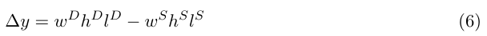

NOTE: contains mathematical notation; text above is the PDF text layer and symbols may be mis-extracted. Image shows the original.

where *w* and *h* is the hourly wage rate and hours worked during a month, respectively, whereas

*l* is the number of months worked during a year. This expression can be rewritten as,

∆*y* = *w<sup>S</sup>h<sup>S</sup>* (*l<sup>D</sup> −l<sup>S</sup>*) | {z } Extensive margin

**equation / math rendering (image)**

NOTE: contains mathematical notation; text above is the PDF text layer and symbols may be mis-extracted. Image shows the original.

+*l<sup>D</sup>*[*h<sup>s</sup>* (*w<sup>D</sup> −w<sup>S</sup>*) | {z } Wage effect

**equation / math rendering (image)**

NOTE: contains mathematical notation; text above is the PDF text layer and symbols may be mis-extracted. Image shows the original.

+*w<sup>D</sup>* (*h<sup>D</sup> −h<sup>S</sup>*) | {z } Intensive margin

**equation / math rendering (image)**

NOTE: contains mathematical notation; text above is the PDF text layer and symbols may be mis-extracted. Image shows the original.

] (7)

where the first component reflects the part of the earnings differential stemming from differences

in employment. The second and third component reflects the possibility that displaced workers

may end up in new jobs paying lower wages or providing fewer hours. This decomposition

may be applied either separately for each year or averaged over some fixed time interval *T*. In

the remainder of Section 4, I unpack the total earnings effect and estimate the effect of layoff

separately on employment, wages and hours worked, following its dynamics and evaluating

its impact over a period of six year period. I then put these pieces of evidence together and

17

Page 23

decompose the earnings losses using equation (7) to evaluate the relative importance of each

adjustment margin.

#### **4.2 Earnings losses by margins of adjustment**

**Extensive margin** Separation from the notifying firm does not mechanically induce non-

employment as workers may well find work, e.g., within their notification period. To provide

more detail on the effects on employment, I take advantage of the monthly employment markers

to trace out the dynamic response. The monthly markers are noisy measures of labor supply

due to some employers (both incumbent and new ones) routinely reporting workers having

started work in January while the actual employment began in, e.g., March. As this type

of measurement error may be more common among displaced workers, estimates should be

interpreted as a lower bound.

Figure 6 a) plots the reduced form probability of non-employment by month relative to no-

tification where again each time point is a separate RD regression. Just as with separation from

the notifying firm, significant differences in non-employment starts 3 months after notification

(as indicated by the vertical dashed red line). These differences remain significant up to 19

months after notification and there are also some significant differences in 26–29 months after

notification. During this time, workers just surpassing the threshold are about 2–4 percentage

points more likely of being non-employed compared to workers within the same order circuit

just below the threshold. Scaling these estimates with the first stage implies that workers that

are displaced are about 16-33 percentage points more likely to experience non-employment in

a given month, 4 to 19 months after notification. From month 30 and onwards, however, em-

ployment differences seems to have subsided as no significant differences can be found within

each respective month.

**Wage effect** Several studies find lower post displacement wages to be an important driver

of long-term earnings losses (see e.g. Lachowska et al., 2020; Schmieder et al., 2023; Jarosch,

2023). To estimate differences in wages between displaced and non-displaced workers, I use the

Swedish wage register which is an annual survey covering about 50 percent of the private sector

workers and all public sector workers. These data contain information on hours worked and full-

time equivalent wages conditional on the worker working at least one hour during a sampling

week between September-November when the data is collected. Due to the wage register being

a random sample (stratified by firm size) of the working population not all employed workers

are observed each year which reduces the sample size substantially, making the estimates more

imprecise.

Figure 6 b) shows the evolution of log wages relative to month of notification for workers

just above and below the threshold. The observed pattern has an interesting connection to the

employment response in Figure 6 a). Wage differences are only visible beyond 30 months after

notification, that is, when the differences in employment rates have subsided. This implies that

18

Page 24

the wage gap reflects a pure wage effect induced by displacement and absent of selection. The

(reduced form) wage gap is estimated to 2.5–2.6 percent in month 40–42 after notification and

significant at the 5 percent level. When scaled by the first stage this would imply that displaced

workers incur on average a 20 percent wage loss on their new job. Interestingly, the effects are

short lasting; after the wage differential starts to appear, workers having just surpassed the

threshold have faster wage growth than their coworkers just below, fully closing the gap about

6 years after notification.

**Hours response** Similar to the analysis on wages, I use the Swedish wage register to esti-

mate differences in hours worked for workers just above and below the threshold. Similar to

Schmieder et al. (2023), I find little evidence of any effect on hours worked following displace-

ment with not significant differences between the two groups at the threshold (not reported).

Unfortunately, data on hours worked are somewhat imprecise and highly variable making it

difficult to draw any solid conclusions about its variation.

**Summary** Table 5 summarize the effect of job loss averaged over a period of 6 years post

notification. Column (1) show estimates from regressing average total earnings loss on displace-

ment *Dic* which has been instrumented with *Zic*. This corresponds to the weighted average of

columns (1)-(6) in Table 4 showing that displaced workers having forgone about 77 thousand

SEK on average each year, 6 years after job loss. Similarly, columns (2)-(4) in Table 5 show

IV-estimates for each margin of adjustment over the 6 years following displacement. Column (2)

indicates that displaced workers work an average of 1.21 months less during the 6 year period

and earn about 4 percent lower wages during this time (column 3),. As expected, however,

the wage effect is not statistically significant as the wage differential only is present during a

short period of time (see Figure 6). The hours response is very imprecisely estimated. If any-

thing displaced workers work somewhat fewer hours, but, I interpret this effect to be of minor

importance in explaining the total earnings loss.

#### **4.3 Decomposing the earnings effect**

I now return to the decomposition of the difference in earnings as described in equation (7)

considering a period of 6 years. I use of the estimates from Section 4.2 to determine the relative

contribution of each adjustment margin. Plugging in the estimates into equation (7) yields

*−*76*.*8 *≈*24*.*5

**equation / math rendering (image)**

NOTE: contains mathematical notation; text above is the PDF text layer and symbols may be mis-extracted. Image shows the original.

**equation / math rendering (image)**

NOTE: contains mathematical notation; text above is the PDF text layer and symbols may be mis-extracted. Image shows the original.

+9*.*9[134

**equation / math rendering (image)**

NOTE: contains mathematical notation; text above is the PDF text layer and symbols may be mis-extracted. Image shows the original.

+ 0*.*17

**equation / math rendering (image)**

NOTE: contains mathematical notation; text above is the PDF text layer and symbols may be mis-extracted. Image shows the original.

] + *ε* |{z}

**equation / math rendering (image)**

NOTE: contains mathematical notation; text above is the PDF text layer and symbols may be mis-extracted. Image shows the original.

39% (8)

where Table 5 provides the estimates plugged into equation (8). The total earnings effect on

the left-hand-side its taken from column (1) whereas estimates to the first, second and third

component on the right-hand-side are taken from column (2), (3) and (4), respectively.

19

Page 25

Over 6 years, about 39 percent of the average losses incurred by a displaced worker can be

attributed to non-employment. The second term multiplies the wage difference of 4.3 percent

with the difference in hourly wage (in thousand SEK) and when multiplied with the months

and hours worked by stayers and leavers, respectively, the wage effect make up only 14 percent

of the average losses over time. Plugging in the point estimate for hours worked suggest that

about 8 percent of the earnings loss comes from reductions in hours, but is measured with a

large error. As I take the left-hand-side of the equation as given and try to predict it by separate

estimates from each margin of adjustment I end up with a residual, being the difference between

the estimated total earnings loss and that predicted jointly by the three adjustment margins.

The share of earnings loss is left unexplained when joining the separate predictions is about 39

percent.

### **5 Understanding earnings losses upon job loss**

The main finding of Section 4, that earnings losses upon displacement are transitory rather

than persistent, appears to be at odds with the standard result in literature. As noted above,

permanent earnings losses following displacement have been found in several different countries

and over multiple time periods.<sup>32</sup> For example, Davis and von Wachter (2011); Lachowska,

Mas and Woodbury (2020) both find that displaced workers in the US have earnings losses

ranging between 15-20 percent up to 20 years after displacement. Although somewhat smaller,

Schmieder, von Wachter and Heining (2023) and Eliason and Storrie (2006); Seim (2019); Athey

et al. (2023) also find substantial long-term earnings losses in Germany and Sweden, respectively.

Finally, Bertheau et al. (2022) document similar earnings pattern after displacement in several

European countries.

To better understand what drives earnings losses upon job loss and its persistence, I start

by estimating earnings losses for workers displaced during mass layoff using the standard dis-

tributed lag model, following the conventional definitions and sample restrictions of the litera-

ture. The aim of this exercise is to provide estimates that are comparable to previous studies

and to verify that there is nothing special in the Swedish context or the particular time period

I study which render earnings losses to be transitory. The result from this exercise replicates

the standard finding of large and highly persistent earnings losses which begs the question; why

are the long-run earnings losses so different between the two settings?

First, I explore if compositional differences across the two samples could account for the

difference in long-run outcomes. To this end, I reweight the conventional mass layoff estimates

to mimic the LIFO sample on observable characteristics. Second, I address the fact that the

identifying variation in the canonical mass layoff estimator and the RD-estimator differes in

that the former exploits variation across firms and the latter within firms, thus making it two

potentially very different experiments. To account for this, I combine the two estimators into

one, by matching workers in the LIFO sample who are below the threshold to workers in non-

32Table A.1 lists some of the most recent and influential studies estimating earnings losses upon displacement.

20

Page 26

downsizing firms, creating a control group similar to that of the previous literature. Finally, to

probe the impact of the size of layoff, I estimate earnings losses using the original LIFO sample,

pooling layoffs by size into quartiles.

#### **5.1 Estimating earnings losses using mass layoff**

Using the matched employer-employee data, I follow Jacobson, Lalonde and Sullivan (1993)

and define a mass layoff to be an event where at least 30 percent of the workforce leaves a

plant within in a year *t*. To be sure that 30 percent is indeed a significant event, I consider

only plants with 50 or more employees in a given year as smaller firms are subject to larger

percentage fluctuations in employment. I define a workers’ main employer as being the one

which gives him the highest earnings in a year and the worker is displaced if he is notified in

year *t* and leaves the establishment between year *t* and *t*+1 or *t*+2 and do not reappear at the

displacing establishment within subsequent 4 years.<sup>33</sup> Finally, to facilitate comparisons with

the earlier literature I consider only male workers between age 25 to 55 with at least 5 years of

(consecutive) tenure.

To create a control group for displaced workers, I sample all workers from plants which

did not carry out a mass layoff.<sup>34</sup> I then restrict attention to workers satisfying the baseline

restrictions made on the displaced workers and use propensity score matching and match workers

on 2-digit industry, tenure, age, earnings in *t −*2*, t −*3 and *t −*4, separately by each year of

displacement. Using a nearest-neighbor algorithm each displaced worker is then assigned a

comparison worker (without replacement) in a non-displacing firm. This yields a group of

non-displaced workers for whom I can observe their entire work record and who are almost

identical to workers who later become displaced (see Table A.3). A common, although debated,

restriction made on the control group is conditioning them staying employed throughout the

entire sample period. As highlighted by Krolikowski (2018), this renders one to attribute all

future job instability of the treated workers to the initial displacement thus exaggerating the

impact of displacement on earnings losses. I therefore compare displaced workers with and

without this restriction in order to align with the previous literature.

Following standard procedure, I estimate earnings losses upon displacement using a dis-

tributed lag model of the form

*yit* = *γt* + *αi* + *πk* +

**equation / math rendering (image)**

NOTE: contains mathematical notation; text above is the PDF text layer and symbols may be mis-extracted. Image shows the original.

10 X

**equation / math rendering (image)**

NOTE: contains mathematical notation; text above is the PDF text layer and symbols may be mis-extracted. Image shows the original.

*k*=*−*5

**equation / math rendering (image)**

NOTE: contains mathematical notation; text above is the PDF text layer and symbols may be mis-extracted. Image shows the original.

*δkD<sup>k</sup>*

**equation / math rendering (image)**

NOTE: contains mathematical notation; text above is the PDF text layer and symbols may be mis-extracted. Image shows the original.

**equation / math rendering (image)**

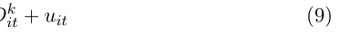

NOTE: contains mathematical notation; text above is the PDF text layer and symbols may be mis-extracted. Image shows the original.

33One limitation in the literature on the consequences of displacement is the inability to separate between involuntary and voluntary separations in matched employer-employee data. This is also one of the main reasons for focusing on high tenured workers. In my main analysis, I make use of the notification data to identify involuntary separations. Figure A.8 b) show results when defining a worker as being displaced as the plant in *t* + 1 or *t* + 2 without conditioning on being notified. Here, short-run earnings losses are somewhat smaller indicating that a non-negligible share of separations are voluntary creating and upward bias. Long-run losses are virtually unchanged.

34I have also experimented with restricting the growth in the non-displacing establishments as in e.g. Flaaen et al. (2019). The results remain unchanged (results available upon request).

21

Page 27

where *yit* is annual earnings for worker *i* in year *t*. *γt* and *αi* are calendar-year and worker

fixed effects, respectively. The *Dit* are dummy variables equal to 1 in the *k<sup>th</sup>* year relative

to displacement, where *k* = *−*3 is the baseline year. Following Schmieder, von Wachter and

Heining (2023), I also include *πk* which are fixed effects for year relative to baseline year. The

coefficients of interest are the *δk* which reflect differences in annual earnings between displaced

and non-displaced workers by each year relative to the baseline year.

#### **5.1.1 Results**

Figure 7 shows the difference in earnings by pooling workers displaced 2005-2015 along with

their matched non-displaced workers. Due to propensity score matching, both groups have

almost identical trends in annual earnings in the pre-displacement period, suggesting that the

matching procedure along with individual fixed effects has created a comparable control group.

The solid black line shows the earnings differential between displaced and non-displaced workers

when not conditioning on the control group being employed in *t >* 0 (as in e.g. Schmieder, von

Wachter and Heining, 2023). The dashed line show the same differential, but, conditional on

non-displaced workers remaining employed with same employer throughout the sample period

(as in e.g. Lachowska, Mas and Woodbury, 2020).

Initial earnings losses of displaced workers amount to a little more than 73 thousand SEK two

years after the layoff event which corresponds to about 25 percent of pre-displacement income.

As time goes by, displaced workers recover some of their initial losses but even after 10 years the

earnings differential between displaced and non-displaced workers are on average about 41,000

SEK (14.2 percent). The wage losses 10 years after notification amount to about 5 percent

(see Figure A.8). These results are very similar to what has previously been found for mass

layoffs in Sweden (c.f. Athey et al., 2023; Seim, 2019; Eliason and Storrie, 2006). In line with

Krolikowski (2018), I also find that a key factor in explaining the high persistence of earnings

losses lies in the handling of the control group. The dashed line in Figure 7 shows estimates

conditioning on future employment of the non-displaced workers. This increases earnings losses

20.8 percent of pre-displacement earnings.

In the Appendix, Figure A.8 show results from several robustness checks on the mass layoff

analysis. Estimates are unaffected by lowering the worker tenure restriction to 3 years. Treating

also non-notified workers as displaced lowers initial earnings losses while long-run losses are

virtually unchanged. As the LIFO analysis in Section 4 exclude plant closures, I exclude these

from the mass layoff analysis to make the estimates more comparable. This only affects losses

directly in the year after displacement while again long-run losses remain unaffected.

In summary, the results suggests that there is nothing particular about the Swedish context

or time period which could explain the absence of long-term earnings losses in the main analysis.

22

Page 28

#### **5.1.2 Reweighting mass layoff estimates**

As seen in Table 1, the LIFO-sample used in the RD analysis differ from the mass layoff sample

having applied the typical restrictions in the literature. In particular, workers in the latter

sample are on average almost 4 years older, work in larger firms and have almost twice as long

tenure. Furthermore, the two samples differ in industry composition. To determine to what

extent differences along these dimensions contribute to the difference in the earnings gap, I

use a weighting produce, following DiNardo, Fortin and Lemieux (1996) (henceforth DFL), to

reweight the mass layoff sample to match the LIFO sample.<sup>35</sup> This amounts to estimating a

probit regression in data combining the two samples where the dependent variable is an indicator

for belonging to the LIFO-sample. From this regression, I obtain a propensity score ˆ*p*(*x*) which

I use to reweight the mass layoff sample by *ϕ*(*x*) = ˆ*p/*(1 *−*ˆ*p*).<sup>36</sup>

Figure 8 plots the estimated earnings gap applying the weighting scheme where the blue

dashed line depicts estimates reweighted on the worker characteristics; age, age squared, level of

education, immigrant status, gender, tenure and tenure squared. The original (unconditional)

estimates (same as in Figure 7) are shown in black for comparison. Reweighting the sample on

while long-run losses decrease by about 30 percent (year 7–10). Nevertheless, despite this

The red line in Figure 8 weights in addition to worker characteristics on the log of establishment

size and industry composition whereas the green line also reweight on year of layoff to hold

constant overall economic conditions. The latter adjustment increases the short-run losses

substantially due to putting more weight on years of the Great Recession, very much consistent

with Schmieder, von Wachter and Heining (2023) finding that earnings losses are larger in

These results suggest that only a small part of the difference in the earnings gap between

the canonical event-study approach using mass layoffs and the RD analysis can be explained by

differences in worker characteristics. After adjusting for compositional differences, permanent

earnings losses are still present even 10 years after layoff suggesting that mass layoffs, in contrast

to smaller redundancies, render permanent earnings losses primarily for other reasons.

#### **5.2 Event study vs. RD estimator**

A key difference between the canonical mass layoff estimator and the RD is that the former

exploits variation across establishments and the latter within establishment. Thus, the two es-

timators focuses on two potentially very different experiments. In the LIFO analysis, treatment

consists of being displaced *contingent* on working at a distressed establishment whereas the tra-

ditional estimator captures the effect of displacement *and* working at a distressed establishment.

35This is very much inspired by and follows Illing, Schmieder and Trenkle (2021) who use the same procedure to study the post displacement gender earnings gap.

36Table A.4 present average characteristics of the mass layoff sample reweighted to mimic the LIFO-sample.

23

Page 29

This as the matched control group in the latter consists of workers in relatively more stable

firms. Although there is little indication of the earnings gap in the RD analysis closing due to

workers below the threshold getting laid off at a later point in time (see Figure 3 and Figure

A.7), remaining at a distressed firm may imply smaller wage growth compared to working at

a more stable firm, which could potentially explain the discrepancy in results. An additional

difference between the two estimators, although more subtle, is that the traditional estimator

identifies the effect for the average displaced worker, whereas the RD analysis pertains to the

marginally displaced worker.

In an effort to align the two estimators, I combine the two approaches by matching workers

below the threshold to workers at more stable firms (similar to the typical control group used in

the literature). Again, using a nearest-neighbor algorithm, I match each worker to an “identical

twin” working at a relatively stable firm which I define as establishment growth in the interval

*±*5 percent, as in Flaaen, Shapiro and Sorkin (2019). Each twin then replaces the original

observation and is assigned the same relative ranking in the order circuit. I match workers on

age, age squared, earnings in *t* to *t −*3, all within year of notification, occupation, tenure and

industry cells. This renders a matched sample almost identical to the original workers below

the threshold (see Table A.6) and as a consequence the “twins” just below and the (original)

workers just above the threshold are also balanced in terms of observables (see Table A.7). This

combined estimator thus relies on across establishment variation and would then capture any

additional effect of working at a distressed establishment while also estimating earnings losses

for the marginally displaced worker.

Figure 9 a) illustrates the first stage of this combined estimator where the black dots left of

the threshold are the identical twins of the original workers below the threshold (shown I gray)

and workers to the right of the threshold are from the original sample (same as in Figure 2).

Naturally, using workers at more stable firms as the contra factual renders a larger first stage

where the probability displacement jumps by 34.7 percentage points just at the threshold.

The effect of displacement on future earnings is shown in Figure 9 b) where I plot IV-

estimates having instrument displacement with the indicator for being above the threshold,

again controlling linearly for workers relative rank. The black solid line shows the earnings gap

using the matched control group whereas the red hollow circles show the original IV-estimates

(without confidence intervals) from Table 4 for comparison. Displaced workers when compared

to workers in non-downsizing firms (the matched sample) do suffer about as large earnings

losses initially as when using within establishment variation. However, the following recovery is

somewhat slower rendering a larger earnings gap beyond *t*+1. This may be due to non-displaced

workers in downsizing firms having on average lower wage growth than non-displaced workers

in more stable firms. Nevertheless, displaced workers do on average seem to recover with the

earnings gap turning insignificant 7 years after notification and is more or less closed after 10

years.

A novel feature of this new estimator is that in contrast to the previous literature who

24

Page 30

has exploited mass layoffs as an instrument for displacement, it relies in the LIFO rules which

enables the study of smaller sized layoffs. The dashed lines in Figure 9 b) splits the sample into

have about the same earnings dynamics during the first 4 years, but their recovery pattern is

quite different thereafter. While workers laid off in smaller layoffs recover and close the earnings

gap around 7 years after notification, workers displaced in large layoffs earn at that time about

50 thousand SEK less compared to similar non-displaced workers (in stable firms). In terms

of magnitude, these long-run losses are also very similar to those found using the standard

approach in section 5.1.<sup>37</sup> Moreover, the recovery for these workers appear to stagnate beyond

7 years after layoff.

These results suggests that although the choice of control group (across or within establish-

ment) can matter for the average size of the earnings losses, it cannot account for the transitory

pattern seen in section 4. Instead, the size of layoff appear to be a key determinant in replicating

the earnings gap as permanent earnings losses can only be found among workers displaced in

large layoffs. Thus, mass layoffs appear to be something fundamentally different than displace-

ments due to more regular adjustments to employment, generating more severe consequences

for displaced workers.

#### **5.3 Earnings losses by size of layoff**

If large layoffs do render more severe consequences for workers, the pattern should also be

visible within the LIFO sample. Therefore, I use the LIFO thresholds and estimate earnings

losses, pooling layoffs by size.<sup>38</sup> This analysis has the advantage of holding constant any specific

sample restrictions or caveats imposed in the RD analysis (see section 2.1), thus making sure

that an absence of a long-run earnings effect cannot be attributed to these factors.

Figure 10 a) and b) plots the earnings dynamics for workers above (solid line) and below

(dashed line) the threshold for small and large layoffs, respectively, where again each time

point correspond to a separate (reduced form) regression with the vertical dashed line indicates

significance at the 5 percent level. Although somewhat imprecisely estimated due to splitting

the sample in two (below/above the median), the figures reveal striking heterogeneity across

layoffs. Whereas workers displaced in smaller redundancies close the earnings gap 6 years and

thereafter earn more than their former coworkers, workers laid off in large layoffs lack the same

recovery and have an average estimated (reduced form) earnings gap of 13,000 SEK, 7 to 10 years

after notification. Noteworthy, is that the difference seem to occur due to workers above the

37Figure A.9 plots for comparison these estimates along with the ones attained in Figure 7 the using the standard approach. For the short run earnings gap the standard approach renders smaller losses which could to a large extent be explained differences in the timing of layoff (see Figure 8). Figure A.9 also show estimates when reweighting the large layoffs to mimic the smaller ones in terms of the composition of worker, industry and year of notification. This changes the estimates only marginally.

38Size of layoff is defined as the number of notified workers divided by the total number of workers at an establishment. The number of notified workers is thus summed over potentially several different order circuits within the same establishment.

25

Page 31

threshold having different recovery patterns in small *vis-`a-vis* large layoffs while their respective

control groups to a large extent are at similar earnings levels 6 years after notification. This

again suggests the effect is not driven by the control group getting displaced at a later point

in time but rather that workers displaced in smaller layoffs recover faster in contrast workers

loosing their job in large layoffs.

To gain precision, Figure 10 shows estimates of differences in long-run earnings, pooling

years 7–10 after notification for small and large layoffs, respectively. This indicates that workers

above the threshold who are displaced in large layoffs earn on average 10,000 SEK less than their

former coworkers just below the threshold, significant at the 10 percent level. The corresponding

IV-estimate implies that displaced workers earn 66,000 SEK less than their non-displaced former

coworkers, which is roughly the same magnitude of long-run losses seen in section 5.1 and 5.2

using alternative empirical strategies.

To probe the pattern further, Figure 10 also show estimated earnings losses splitting the

sample into quartiles of size (solid circles).<sup>39</sup> Strikingly, there is a clear (monotonic) negative

correlation between the size of layoff and long-run earnings losses. Among the largest layoffs

(Q4), workers above the threshold earn on average 14,800 less than their former coworkers

below the threshold. (*p* = *.*089). In contrast, workers displaced in the smallest layoffs (Q1)

earn 17,500 more then there former colleagues (*p* = *.*056).<sup>40</sup> To what extent is this correlation

driven by compositional differences across layoffs? To answer the red circles show estimated

earnings losses when adjusting for difference (relative to workers in *Q*2) in worker and industry

composition as well as time of layoff, using the DFL-reweighting scheme as in section 5.1.2.<sup>41</sup>

Doing so does render a slight increases of the long-run earnings gap for workers displaced in

large layoffs, turning significant at the 10 and 5 percent level for Q3 and Q4, respectively, but

does not alter the overall pattern.

### **6 Sources of permanent earnings losses in mass layoffs**

Why do larger layoffs bring about greater and more permanent earnings losses? On the one

hand, at the individual level, larger layoffs may reduce negative signals to employers which in

turn could reduce workers earnings and employment losses (Gibbons and Katz, 1991). On the

other hand, large layoffs may cause workers to lose a larger share of their human capital if larger

layoffs are e.g. more frequent in industries where the degree of firm specific human capital is

high or if workers in these layoffs have certain characteristics which negatively influence future

earnings. On the aggregate, mass layoffs tend to be more frequent during periods of economic

distress and earnings losses tend larger for workers laid off during economic recessions (Davis

and von Wachter, 2011; Schmieder, von Wachter and Heining, 2023). However, as shown above,

while these mechanisms help explain the overall cost of jobs loss they seem unable to account

39In the Appendix, Figure A.10 show the negative correlation between estimated earnings losses and size of layoff even more granularly.

40The difference in estimated earnings gap between the unweighted Q1 and Q4 is 32,320 SEK with *p* = *.*010. 41Table A.5 in Appendix A show summary statistics for the unweighted and weighted samples.

26

Page 32

for the *difference* in long-run earnings losses between mass layoffs and smaller redundancies as

these remain after adjusting for worker and industry composition as well as the time of layoff.

One possibility is that differently sized layoffs generate differences in other post-displacement

outcomes which are correlated with lower earnings. Table 6 provides IV-estimates from the

discontinuity separately for small and large layoffs, where the latter have again been reweighted

to mimic smaller layoffs. The first row of Table 6 reiterates the earnings pattern seen above with

short-run losses being more or less equal for displaced workers in small and large layoffs, while

in the long-run permanent losses are only present among workers displaced in large layoffs. In

square brackets below each set of estimates is the *p*-value from testing equality between the two

estimates.

Driving the difference between large and small layoffs appear to be exposure to non-

employment. Both in the medium and long-run, workers displaced in large layoffs are exposed

to more non-employment and are more likely to be registered as unemployed than their non-

displaced coworkers. The latter effect is also significantly different across layoff size in the

long-run. As expected, displaced workers have a higher probability of having switched indus-

try and occupation compared to their non-displaced former coworkers. Interestingly, workers

displaced in large layoffs have a significantly higher probability of working in another region

compared to where they were displaced and are less likely to live and work in the same region.

The latter effect is significantly different across small an large layoffs at the 10 percent level

(*p* = *.*055). In contrasts to e.g. Schmieder, von Wachter and Heining (2023), I detect no signif-

icant differences in wages or firm size between previously displaced and non-displaced workers.

However, both outcomes are already to begin with highly variable and thus partitioning the

data into three groups further exacerbates the problem. Thus the results should be interpreted

with caution.<sup>42</sup>

Overall, there are few detectable differences in post employment outcomes between workers

displaced in small *vis-a-vis* large layoffs. What stands out is large layoffs rendering more

exposure to non-employment and increasing the probability to find employment in another

region. One interpretation of these findings, in line with Gathmann et al. (2018), is that large

layoffs may have an impact on the entire local labor market, prolonging non-employment and

making workers more prone to find work elsewhere. I examine the role of non-employment and

the local labor market in the following sections.

#### **6.1 The role of non-employment**

Recent work by Schmieder, von Wachter and Heining (2023) and Fallick et al. (2021) show

that non-employment duration is a key factor in explaining earnings losses after displacement.

Also, Burdett et al. (2020) and Jarosch (2023) suggest that the loss (or forgoing) of human

capital while unemployed is a key contributor to permanent earnings losses. Thus, for a given

42I have examined several other dimensions of firms such as firm value-added, profits, revenue as well as both firm and establishment FE’s estimated using AKM. None of these outcomes show any significant difference in outcomes, neither between displaced an non-displaced workers, nor across layoff size.

27

Page 33

worker, getting displaced in a mass layoff may render worse outcomes if it causes longer peri-

ods of unemployment, rendering depreciation of human capital and/or potentially discouraging

the worker from participating in the labor market all together. Figure 11 a) and b) show the

probability of becoming long-term unemployed after layoff while c) and d) show the likelihood

of workers having left the labor force.<sup>43</sup> The outcomes are shown separately by size of layoff

where large layoffs are again reweighted to match the worker and industry composition among

the smaller layoffs as well as the time of layoff to account for differences in overall economic

conditions. The top panel of Figure 11 reveals that workers just above the threshold in large

layoffs are more likely to become long-term unemployed in the year following notification com-

pared to their coworkers just below the threshold. Interestingly, no such difference is observed

at the discontinuity among the smaller layoffs. The bottom panel show the evolution of workers

having left the labor force, relative to time of notification. Also here, there is no discernible

is worth reemphasizing that these estimates are reweighted to match the worker composition

among workers in smaller layoffs, in particular on age and tenure.<sup>44</sup>

The finding that non-employment and zero earnings contribute a lot to the persistence of

earnings losses is not new. Again, both Schmieder et al. (2023) and Fallick et al. (2021) who

show that workers non-employment duration plays key role in explaining for the magnitude and

persistence in earnings losses after displacement. Furthermore, Flaaen et al. (2019) shows that

excluding zero earnings observations render long-run earnings losses of only about a third of

those observed when accounting for non-employment. However, the fact that large layoffs, in

contrast to smaller ones, render longer unemployment duration and cause substantial discour-

agement among workers is to the best of my knowledge new to the literature.<sup>45</sup>

#### **6.2 The role of local labor markets**

Trivially, the key difference between small and large layoffs is the sheer number of workers

getting displaced. As such, in a mass layoff, more workers with the same type of skills become

unemployed and in general compete for the same type of jobs. This type of labor congestion

43Having left the labor force is defined as, for a given year, having zero earnings and not being registered as unemployed at the PES.

44Whereas the upward trend is driven by workers being near retirement age, the difference remain roughly the same when restricting the sample to workers aged 18–55 (see Figure A.11 in Appendix A). This is indeed expected as aged is balanced across the threshold.

45When estimating distributed lags models with a matched control group, Fallick et al. (2021) finds that workers separating from non-distressed firms have similar, and quite surprisingly, perhaps even larger earnings losses compared to workers separating from distressed firms. My results do not corroborate this finding, which in turn also stands in contrast to those of Jacobson, Lalonde and Sullivan (1993). Unfortunately, Fallick et al. (2021) are unable to evaluate to what extent their result could be accounted for by workers in small layoffs being more adversely selected as they lack data on worker characteristics (aside form gender and age). Moreover, unlike in Flaaen et al. (2019) who through survey data have the individuals’ reported reason for separation, it is impossible to asses to what extent the result is driven by separations in non-distressed firms being more likely to be due to worker choice and firings for cause; which is one of the biases aimed to be avoided by focusing on mass layoffs (Couch and Placzek, 2010).

28

Page 34

would not only prolong unemployment but also make workers more prone to find work outside

the local labor market. Furthermore, as shown by Gathmann et al. (2018), mass layoffs may have

negative spillovers, bringing about additional employment losses as other firms, in particular

in the same industry, are either forced to downsize or abstain from hiring. This would further

increase competition and limit the amount of jobs available which, as shown by Gulyas and

Pytka (2020), is a key determinant of post displacement earnings losses.

Layoffs that are large relative to size of the establishment are also typically large in relation

to the local labor market and industry.<sup>46</sup> As such, mass layoffs may have an impact the entire

local labor market. Figure 12 shows worker earnings relative to displacement splitting layoffs

not only by size relative to the establishment (as in Figure 10), but also by the size of the

downsizing firms’ industry in the local labor market.<sup>47</sup> One may view the latter partition as the

importance of a particular industry to employment in a local labor market. As seen in panel

a) and b), splitting small layoffs by the size of the industry matters little for long run earnings

losses. Nevertheless, there is some indication that getting displaced in a small layoff from a firm

operating in one of the (locally) larger industries may even be beneficial for the worker in the

long run. One potential explanation could be that workers who are being displaced from firms

doing poorly could instead quite easily transfer their skills to new firms with better prospects.

Panel c) and d) in Figure 12 partitions large layoffs into small and large industries, respec-

tively. Interestingly, workers laid off in large layoffs but in relativity smaller industries have

overall small earnings losses and no sign of permanent scarring. In contrast, earnings losses

are both large and permanent among workers displaced in large layoffs where the industry of

the downsizing firm account for a large share of total employment in the local labor market. I

interpret these results as even though a layoff may be large in terms of a the share of the work-

force getting displaced, there are other alternative employers and industries able to absorb the

unemployment shock. In contrast, once a layoff is both large and occurs in one of the (locally)

dominating industries, overall demand drops and workers get exposed to more non-employment

causing discouragement and loss of human capital.

### **7 Conclusions**

This paper examines the question of how workers are affected by job loss in terms of their future

earnings, wages and employment. The empirical approach builds on exploiting discontinuities

in the probability of displacement generated by a last-in-first-out (LIFO) rule used at layoffs

in Sweden. Whereas current evidence almost exclusively pertain to workers displaced in mass

layoffs and plant closures, the new research design employed in this paper allows me to study

46Figure A.12 in the Appendix plots the correlation between size of layoff relative to the establishment against the size relative to the local labor market (in logs) as defined by 1-digit industry and municipality. The slope coefficient is *β* = 0*.*398 (0.011).

47The split between small and large is done at the median in each distribution such that a large layoff corresponds to downsizing by more than 20 percent of the workforce whereas a large industry (one digit level) employs at least 18.2 percent of all employed in the local labor market.

29

Page 35

the effects of job loss for both smaller redundancies and large (mass) layoffs.

I find that displaced workers suffer substantial earnings losses during the first two years after

displacement compared to their non-displaced coworkers. However, on average, workers recover

fully within 7 years after being laid off. Importantly, this not driven by initially non-displaced

workers loosing their job at later point in time but rather that displaced workers climb back up

the job ladder, experiencing faster wage growth.

As these findings stand in contrast to the standard result in the literature of permanent earn-

ings losses after displacement, I probe this result in great detail. First, I replicate the canonical

mass layoff approach (Jacobson, Lalonde and Sullivan, 1993) finding large and persistent earn-

ings losses, also when accounting for differneces in sample composition. Second, I construct a

new estimator, combining the traditional mass layoff estimator and the RD-design, to account

for differences in estimation strategies and contra factual states. I find that workers on average

recover from displacement, but workers displaced in large (mass) layoffs suffer long run earn-

ings losses. Third, estimating worker earnings losses separately by size of layoff again reveal

that permanent losses are only found among workers displaced in large layoffs whereas workers

displaced in smaller redundancies could potentially even benefit from job loss in the long-run. I

Finally, I find that large layoffs render workers more exposed to non-employment, (long-term)

unemployment and have and higher probability of leaving the labor force and switching local

labor market.

Taken together, these results suggests that displacement due to mass layoff is different from

job loss due to smaller and far more common redundancies and that permanent worker scarring

may not be as ubiquitous a phenomenon as previous research may have lead one to believe.

Still, I see my findings as being consistent with much of the recent literature exploring the

sources of long-term earnings losses after a mass layoff. In particular, Gathmann et al. (2018)

showing how firms in the same industry as a mass layoff plant suffer from negative spillovers

and Burdett, Carrillo-Tudela and Coles (2020) and Jarosch (2023) showing how displacement

render longer and serially correlated unemployment spells where workers lose human capital.

This paper sheds new light on the question on how workers are affected by job loss and

whether displacement create lasting scars or merely temporary blemishes. While the former

shows every sign of being true for workers displaced in large layoffs, for the vast majority of

job loss occurring in smaller sized layoffs, workers eventually recover from the adverse shock.

These findings raise questions about the generalizability of results based on mass layoffs. Given

its widespread use as an instrument for job loss in identifying the consequences on various

outcomes such as health, mortality, crime, etcetera, more research is needed to understand how

the size of layoff influence worker outcomes and what role local labor market conditions play

in determining its severity.

30

Page 36

### **References**

**Abadie, Alberto, Joshua Angrist, and Guido Imbens**, “Instrumental variables estimates

of the effect of subsidized training on the quantiles of trainee earnings,” *Econometrica*, 2002, *70* (1), 91–117.

**Abowd, John M, Francis Kramarz, and David N Margolis**, “High Wage Workers and

High Wage Firms,” *Econometrica*, 1999, *67* (2), 251–333.

#### **Athey, Susan, Lisa K. Simon, Oskar N. Skans, Johan Vikstrom, and Yaroslav Yaky-**

**movych**, “The Heterogeneous Earnings Impact of Job Loss Across Workers, Establishments, and Markets,” 2023.

**Bennett, Patrick and Amine Ouazad**, “Job Displacement, Unemployment, and Crime: Ev-

idence from Danish Microdata and Reforms,” *Journal of the European Economic Association*, 10 2019, *18* (5), 2182–2220.

#### **Bertheau, Antoine, Edoardo Maria Acabbi, Cristina Barcelo, Andreas Gulyas, Ste-**

**fano Lombardi, and Raffaele Saggio**, “The Unequal Cost of Job Loss across Countries,” Working Paper 29727, National Bureau of Economic Research February 2022.

**Black, Sandra E., Paul J. Devereux, and Kjell G. Salvanes**, “Losing heart? The effect

of job displacement on health,” *Industrial and Labor Relations Review*, 2015, *68* (4), 833–861.

**B¨ockerman, Petri, Per Skedinger, and Roope Uusitalo**, “Seniority rules, worker mobility

and wages: Evidence from multi-country linked employer-employee data,” *Labour Economics*, 2018, *51*, 48–62.

**Britto, Diogo G. C., Paolo Pinotti, and Breno Sampaio**, “The Effect of Job Loss and

Unemployment Insurance on Crime in Brazil,” *Econometrica*, 2022, *90* (4), 1393–1423.

**Browning, Martin, Anne Moller Dano, and Eskil Heinesen**, “Job displacement and

stress-related health outcomes,” *Health Economics*, 2006, *15* (10), 1061–1075.

#### **Buhai, Sebastian, Miguel A Portela, Coen N Teulings, and Aico van Vuuren**, “Re-

turns to Tenure or Seniority?,” *Econometrica*, 2014, *82* (2), 705–730.

**Burdett, Kenneth, Carlos Carrillo-Tudela, and Melvyn Coles**, “The Cost of Job Loss,”

*The Review of Economic Studies*, 04 2020, *87* (4), 1757–1798.

**Calonico, Sebastian, Matias D. Cattaneo, and Rocio Titiunik**, “Robust Nonparametric

Confidence Intervals for Regression-Discontinuity Designs,” *Econometrica*, 2014, *82* (6), 2295– 2326.

**Carrington, William J. and Bruce Fallick**, “Why Do Earnings Fall with Job Displace-

ment?,” *Industrial Relations*, 2017, *56* (4), 688–722.

**Cederl¨of, Jonas, Peter Fredriksson, David Seim, and Arash Nekoei**, “Mandatory

Advance Notice of Layoff: Evidence and Efficiency Considerations,” *CESifo Working Paper*, 2021, (9208).

**Couch, Kenneth A and Dana W Placzek**, “Earnings Losses of Displaced Workers Revis-

ited,” *American Economic Review*, 2010, *100* (1), 572–589.

**Davezies, Laurent and Thomas Le Barbanchon**, “Regression discontinuity design with

continuous measurement error in the running variable,” *Journal of Econometrics*, 2017, *200* (2), 260–281. Measurement Error Models.

31

Page 37

**Davis, Steven J. and Till von Wachter**, “Recessions and the Costs of Job Loss,” *Brookings*

*Papers on Economic Activity*, 2011, *Fall* (1993), 1–72.

**DiNardo, John, Nicole M. Fortin, and Thomas Lemieux**, “Labor Market Institutions

and the Distribution of Wages, 1973-1992: A Semiparametric Approach,” *Econometrica*, 1996, *64* (5), 1001–1044.

**Eliason, Marcus and Donald Storrie**, “Lasting or latent scars? Swedish evidence on the

long-term effects of job displacement.,” *Journal of Labor Economics*, 2006, *24* (4), 831–856.

**and** , “Does job loss shorten life?,” *Journal of Human Resources*, 2009, *44* (2), 277–302.

**Fackler, Daniel, Steffen Mueller, and Jens Stegmaier**, “Explaining Wage Losses After

Job Displacement: Employer Size and Lost Firm Wage Premiums,” *Journal of the European Economic Association*, 08 2021, *19* (5), 2695–2736.

**Fallick, Bruce C**, “A Review of the Recent Empirical Literature on Displaced Workers,”

*Industrial and Labor Relations Review*, 1996, *50* (1), 5–16.

#### **Fallick, Bruce, John Haltiwanger, Erika McEntarfer, and Matthew Staiger**, “Job Dis-

placement and Job Mobility: The Role of Joblessness,” *Federal Reserve Bank of Cleveland,*, 2021, (Working Paper No. 19-27R).

**Flaaen, Aaron, Matthew D. Shapiro, and Isaac Sorkin**, “Reconsidering the Conse-

quences of Worker Displacements: Firm versus Worker Perspective,” *American Economic Journal: Macroeconomics*, April 2019, *11* (2), 193–227.

**Gathmann, Christina, Ines Helm, and Uta Sch¨onberg**, “Spillover Effects of Mass Lay-

offs,” *Journal of the European Economic Association*, 12 2018, *18* (1), 427–468.

**Gibbons, Robert and Larry Katz**, “Layoffs and Lemons,” *Journal of Labor Economics*,

1991, *9* (4), 351–380.

**Gulyas, Andreas and Krzysztof Pytka**, “Understanding the Sources of Earnings Losses

After Job Displacement: A Machine-Learning Approach,” *Miemo*, 2020.

**Hethey-Maier, Tanja and Johannes F. Schmieder**, “Does the Use of Worker Flows Im-

prove the Analysis of Establishment Turnover? Evidence from German Administrative Data,” *Schmollers Jahrbuch : Journal of Applied Social Science Studies / Zeitschrift f¨ur Wirtschaftsund Sozialwissenschaften*, 2013, *133* (4), 477–510.

**Hijzen, Alexander, Richard Upward, and Peter W Wright**, “The Income Losses of

Displaced Workers,” *The Journal of Human Resources*, 2010, *45* (July 2013), 243–269.

**Huckfeldt, Christopher**, “Understanding the Scarring Effect of Recessions,” *American Eco-*

*nomic Review*, April 2022, *112* (4), 1273–1310.

**Huttunen, Kristiina and Jenni Kellokumpu**, “The Effect of Job Displacement on Couples’

Fertility Decisions,” *Journal of Labor Economics*, 2016, *34* (2), 403–442.

**Illing, Hannah, Johannes F Schmieder, and Simon Trenkle**, “The Gender Gap in

Earnings Losses after Job Displacement,” Working Paper 29251, National Bureau of Economic Research September 2021.

**Jacobson, Louis S, Robert J Lalonde, and Daniel G Sullivan**, “Earnings Losses of

Displaced Workers,” *American Economic Review*, 1993, *83* (4), 685–709.

32

Page 38

**Jarosch, Gregor**, “Searching for Job Security and the Consequences of Job Loss,” *Economet-*

*rica*, 2023, *91* (3), 903–942.

**Jolly, Nicholas A. and Brian J. Phelan**, “The Long-Run Effects of Job Displacement on

Sources of Health Insurance Coverage,” *Journal of Labor Research*, 2017, *38* (2), 187–205.

**Jung, Philip and Moritz Kuhn**, “Earnings Losses and Labor Mobility Over the Life Cycle,”

*Journal of the European Economic Association*, 05 2018, *17* (3), 678–724.

**Kjellberg, Anders**, *Kollektivavtalens t¨ackningsgrad samt organisationsgraden hos arbetsgi-*

*varf¨orbund och fackf¨orbund* number 1. In ‘Studies in Social Policy, Industrial Relations, Working Life and Mobility.’, Department of Sociology, Lund University, may 2019. 2021 ˚ars upplaga av denna ˚arligen publicerade rapport.

**Kletzer, Lori G and Robert W Fairlie**, “The Long-Term Costs of Job Displacement for

Young Adult Workers,” *Industrial and Labor Relations Review*, 2003, *56* (4), 682–698.

**Krashinsky, Harry**, “Evidence on Adverse Selection and Establishment Size in the Labor

Market,” *Industrial and Labor Relations Review*, 2002, *56* (1), 84–96.

**Krolikowski, Pawel**, “Job ladders and earnings of displaced workers,” *American Economic*

*Journal: Macroeconomics*, 2017, *9* (2), 1–31.

, “Choosing a Control Group for Displaced Workers,” *Industrial and Labor Relations Review*, 2018, *71* (5), 1232–1254.

**Kuhn, Andreas, Rafael Lalive, and Josef Zweim¨uller**, “The public health costs of job

loss,” *Journal of Health Economics*, 2009, *28* (6), 1099–1115.

**Lachowska, Marta, Alexandre Mas, and Stephen A. Woodbury**, “Sources of Displaced

Workers’ Long-Term Earnings Losses,” *American Economic Review*, October 2020, *110* (10), 3231–66.

#### **Landais, Camille, Arash Nekoei, Peter Nilsson, David Seim, and Johannes Spin-**

**newijn**, “Risk-Based Selection in Unemployment Insurance: Evidence and Implications,” *American Economic Review*, April 2021, *111* (4), 1315–55.

**Lazear, Edward P**, “Job Security Provisions and Employment,” *Quarterly Journal of Eco-*

*nomics*, 1990, *105* (3), 699–726.

**Lee, David S. and Thomas Lemieux**, “RDD in Economics,” *Journal of economic literature*,

2010, *20* (1), 281–355.

**Lee, Sangheon**, “Seniority as an employment norm: the case of layoffs and promotion in the

US employment relationship,” *Socio-Economic Review*, 01 2004, *2* (1), 65–86.

**Lengerman, Paul A. and Lars Vilhuber**, “Abandoning the Sinking Ship The Composition

of Worker Flows Prior to Displacement,” *LEHD, U.S. Census Bureau*, 2002, *Technical* (TP- 2002-11).

**McCrary, Justin**, “Manipulation of the running variable in the regression discontinuity design:

A density test,” *Journal of Econometrics*, 2008, *142* (2), 698–714.

**Mortensen, D. T. and C. A. Pissarides**, “Job Creation and Job Destruction in the Theory

of Unemployment,” *The Review of Economic Studies*, 1994, *61* (3), 397–415.

**Pfann, Gerard A and Daniel S Hamermesh**, “Two-sided learnings, labor turnover and

worker displacement,” *NBER Working Paper*, 2001, *8273.*

33

Page 39

**Pissarides, Christopher A.**, “Employment protection,” *Labour Economics*, 2001, *8* (2), 131–

159.

**Rege, Mari, Kjetil Telle, and Mark Votruba**, “Parental job loss and children’s school

performance,” *The Review of economic studies*, 2011, *78* (4), 1462–1489.

**Ruhm, Christopher J**, “Are Workers Permanently Scarred by Job Displacements?,” *Ameri-*

*can Economic Review*, 1991, *81* (1), 319–324.

**Schaller, Jessamyn and Ann Huff Stevens**, “Short-run effects of job loss on health condi-

tions, health insurance, and health care utilization,” *Journal of Health Economics*, 2015, *43*, 190–203.

**Schmieder, Johannes F., Till von Wachter, and Joerg Heining**, “The Costs of Job

Displacement over the Business Cycle and Its Sources: Evidence from Germany,” *American Economic Review*, 2023.

**, , and Stefan Bender**, “The Effect of Unemployment Benefits and Nonemployment Durations on Wages,” *American Economic Review*, March 2016, *106* (3), 739–77.

**Schwerdt, Guido**, “Labor turnover before plant closure: ”Leaving the sinking ship” vs. ”Cap-

tain throwing ballast overboard”,” *Labour Economics*, 2011, *18* (1), 93–101.

**Seim, David**, “On the incidence and effects of job displacement : Evidence from Sweden,”

*Labour Economics*, 2019, *57*, 131–145.

**Song, Jae and Till von Wachter**, “Long-Term Nonemployment and Job Displacement,”

*Re-evaluating labor market dynamics: a symposium sponsored by the Federal Reserve Bank of Kansas City*, 2014, pp. 315–388.

**Stevens, Ann Huff**, “Effects of Job Displacement : The Importance of Multiple Job Losses,”

*Journal of Labor Economics*, 1997, *15* (1), 165–188.

**and Jessamyn Schaller**, “Short-run effects of parental job loss on children’s academic achievement,” *Economics of education review*, 2011, *30* (2), 289–299.

**Sullivan, Daniel and Till von Wachter**, “Job Displacement and Mortality: An Analysis

Using Administrative Data,” *Quarterly Journal of Economics*, 2009, *124* (3), 1265–1306.

**von Wachter, Till and Stefan Bender**, “In the Right Place at the Wrong Time : The Role

of Firms and Luck in Young Workers’ Careers,” *American Economic Review*, 2006, *96* (5), 1679–1705.

**, Jae Song, and Joyce Manchester**, “Long-Term Earnings Losses Due to Mass Layoffs During the 1982 Recession : An Analysis Using U . S . Administrative Data from 1974 to 2004,” *IZA/CEOR 11th European summer symposium in labour economics*, 2009.

34

Page 40

### **Figures and Tables**

Figure 1: Graphical illustration of two order circuits

*−*6 *−*5 *−*4 *−*3 *−*2 *−*1 0 1 2 3

**equation / math rendering (image)**

NOTE: contains mathematical notation; text above is the PDF text layer and symbols may be mis-extracted. Image shows the original.

*−*7 *−*6 *−*5 *−*4 *−*3 *−*2 *−*1 0 1 2

**equation / math rendering (image)**

NOTE: contains mathematical notation; text above is the PDF text layer and symbols may be mis-extracted. Image shows the original.

Cut-off

Cut-off

Low tenure High tenure

Notes: The figure illustrates workers relative tenure/seniority ranking, normalized to zero at cut-off, for two different occupations (pink and gray) within an establishment in a given year which together forms two order circuits. Workers right of the cut-off, with positive relative ranking are those who, according to the LIFO rule, ought to be displaced when a firm downsizes due to shortage of work.

Figure 2: Probability of having left notifying firm

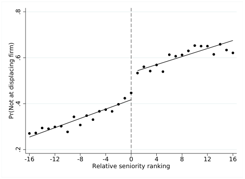

NOTE: figure/graphic rendered as an image from the PDF; its content is not machine-readable text. Caption (if any) follows as the next block.

**text found inside the figure**

.2 .4 .6 .8 Pr(Not at displacing firm)

-16 -12 -8 -4 0 4 8 12 16 Relative seniority ranking

Notes: The figure shows the probability of displacement as a function of a workers relative ranking within an order circuit (in discrete bins), normalized to zero at the threshold. The regression comes from estimating equation (3) with a linear control function interacted with the threshold, using a bandwidth of *±*16. The regression also includes baseline covariates: age, age squared, gender, immigrant status, educational attainment FE:s as well as order circuit FE:s. The point estimate of the jump at the threshold is 0.119 with a standard error of 0.015 which corresponds to an F-statistic of 61.98. Standard errors are clustered at the order circuit level.

35

Page 41

Figure 3: Probability of having left notifying firm relative month of notification

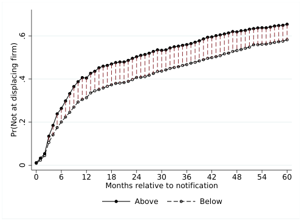

NOTE: figure/graphic rendered as an image from the PDF; its content is not machine-readable text. Caption (if any) follows as the next block.

**text found inside the figure**

0 .2 .4 .6 Pr(Not at displacing firm)

0 6 12 18 24 30 36 42 48 54 60 Months relative to notification

Above Below

Notes: The figure shows the probability of having left the notifying firm for a given month relative the month of notification. For each time point, I plot the constant (hollow circles) and constant+*γ* (solid circles) estimate of equation (3) which corresponds to the average predicted value of each outcome for workers just to the left and right of the threshold, respectively. The dashed vertical line indicates significance at the 5-percent level where standard errors are clustered at the order circuit level. The regressions use a bandwidth of *±*16 and include a linear control function interacted with the threshold as well as baseline covariates: age, age squared, gender, immigrant status, educational attainment FE:s and order circuit FE:s.

Figure 4: Annual earnings by relative seniority ranking

(a) 1 year after notification

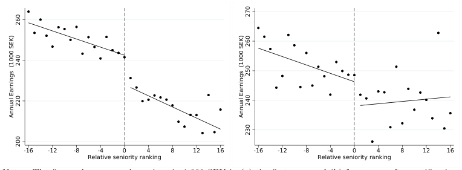

NOTE: figure/graphic rendered as an image from the PDF; its content is not machine-readable text. Caption (if any) follows as the next block.

**text found inside the figure**

200 220 240 260 Annual Earnings (1000 SEK)

-16 -12 -8 -4 0 4 8 12 16 Relative seniority ranking

230 240 250 260 270 Annual Earnings (1000 SEK)

-16 -12 -8 -4 0 4 8 12 16 Relative seniority ranking

(b) 4 years after notification

Notes: The figure shows annual earnings in 1,000 SEK in (a) the first year and (b) four years after notification as a function of workers’ relative ranking within an order circuit (in discrete bins), normalized to zero at the cut-off. The regressions comes from estimating equation (3) with annual earnings as the dependent variable, using a bandwidth of *±*16 and including a linear control function interacted with the threshold. The regressions also includes the baseline covariates: age, age squared, gender, immigrant status, educational attainment FE:s as well as order circuit FE:s.

36

Page 42

Figure 5: Evolution of annual earnings relative to year of notification

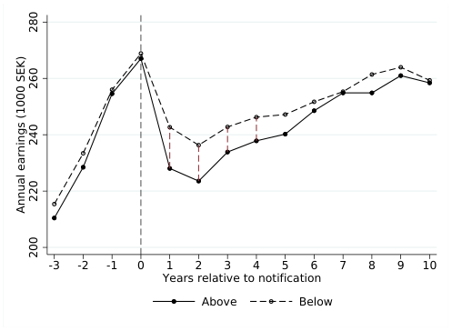

NOTE: figure/graphic rendered as an image from the PDF; its content is not machine-readable text. Caption (if any) follows as the next block.

**text found inside the figure**

200 220 240 260 280 Annual earnings (1000 SEK)

-3 -2 -1 0 1 2 3 4 5 6 7 8 9 10 Years relative to notification

Above Below

Notes: The figure shows annual earnings relative to the year of notification. For each time point, I plot the constant (hollow circles) and constant+*γ* (solid circles) estimate of equation (3) with annual earnings as the dependent variable which corresponds to the average predicted value of each outcome for workers to the left and right of the threshold, respectively. The dashed vertical line indicates significance at the 5-percent level where standard errors are clustered at the order circuit level. All regressions use a bandwidth of *±*16 and include a linear control function interacted with the threshold and baseline covariates: age, age squared, gender, immigrant status, educational attainment FE:s as well as order circuit FE:s.

Figure 6: Evolution of non-employment and wages by month relative to notification

(a) Non-employment

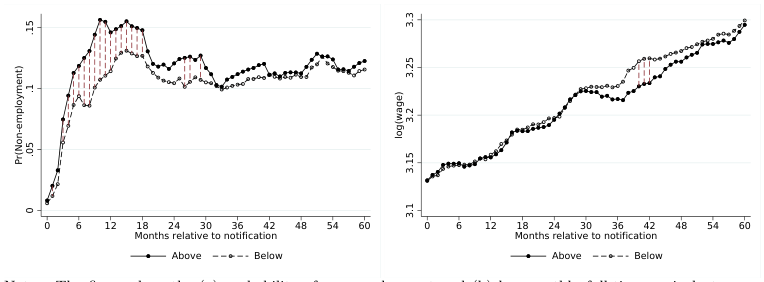

NOTE: figure/graphic rendered as an image from the PDF; its content is not machine-readable text. Caption (if any) follows as the next block.

**text found inside the figure**

0 .05 .1 .15 Pr(Non-employment)

0 6 12 18 24 30 36 42 48 54 60 Months relative to notification

Above Below

3.1 3.15 3.2 3.25 3.3 log(wage)

0 6 12 18 24 30 36 42 48 54 60 Months relative to notification

Above Below

(b) log(monthly wage)

Notes: The figure show the (a) probability of non-employment and (b) log monthly full-time equivalent wage for a given month relative the month of notification. For each time point, I plot the constant (hollow circles) and constant+*γ* (solid circles) estimate of equation (3) which corresponds to the average predicted value of each outcome for workers just to the left and right of the threshold, respectively. The dashed vertical line indicates significance at the 5-percent level where standard errors are clustered at the order circuit level. All regressions use a bandwidth of *±*16 and include a linear control function interacted with the threshold and baseline covariates: age, age squared, gender, immigrant status, educational attainment FE:s as well as order circuit FE:s.

37

Page 43

Figure 7: Earnings losses upon mass layoff

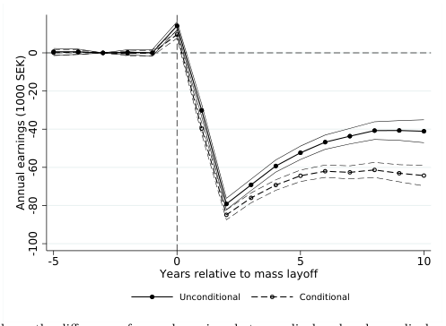

NOTE: figure/graphic rendered as an image from the PDF; its content is not machine-readable text. Caption (if any) follows as the next block.

**text found inside the figure**

-100 -80 -60 -40 -20 0 Annual earnings (1000 SEK)

-5 0 5 10 Years relative to mass layoff

Unconditional Conditional

Notes: The figure shows the difference of annual earnings between displaced and non-displaced workers by years relative to a mass layoff event where earnings is normalized to zero at *t −*3. Displacement is defined as a worker being notified and leaving the plant in year *t* + 1 or *t* + 2 during a mass layoff event. The plotted estimates are *δk* from equation (9) along with 95 percent confidence intervals where standard errors are clustered at the individual level. The solid black line show losses of displaced workers when not conditioning on the control group being employed in *t >* 0. The dashed black line conditions on the control group being employed throughout the entire sample period. Standard errors are clustered at the individual worker level.

Figure 8: Reweighted earnings losses upon mass layoff

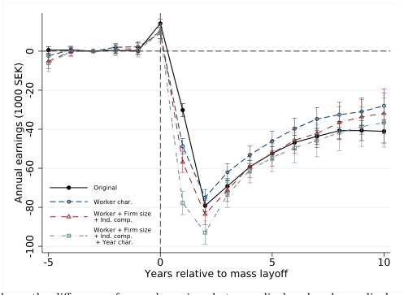

NOTE: figure/graphic rendered as an image from the PDF; its content is not machine-readable text. Caption (if any) follows as the next block.

**text found inside the figure**

-100 -80 -60 -40 -20 0 Annual earnings (1000 SEK)

-5 0 5 10 Years relative to mass layoff

Original

Worker char.

Worker + Firm size + Ind. comp.

Worker + Firm size + Ind. comp. + Year char.

Notes: The figure shows the difference of annual earnings between displaced and non-displaced workers by years relative to a mass layoff event where earnings is normalized to zero at *t −*3. Displacement is defined as a worker being notified and leaving the plant in year *t*+1 or *t*+2 during a mass layoff event. The plotted estimates are *δk* from equation (9) along with 95 percent confidence intervals where standard errors are clustered at the individual level. The solid black line replicate the (unconditional) estimates of Figure 7. The dashed, blue, red and teal line reweights the original estimates to mimic LIFO-sample in various dimensions to account for compositional differences between the mass layoff and LIFO-sample. Standard errors are clustered at the individual worker level.

38

Page 44

Figure 9: Matched worker sample

(a) First stage with matched sample for workers below threshold

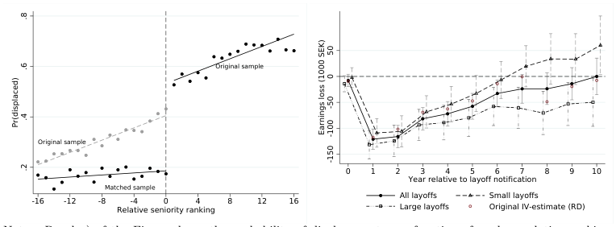

NOTE: figure/graphic rendered as an image from the PDF; its content is not machine-readable text. Caption (if any) follows as the next block.

**text found inside the figure**

Matched sample

Original sample

Original sample

.2 .4 .6 .8 Pr(displaced)

-16 -12 -8 -4 0 4 8 12 16 Relative seniority ranking

-150 -100 -50 0 50 Earnings loss (1000 SEK)

0 1 2 3 4 5 6 7 8 9 10 Year relative to layoff notification

All layoffs Small layoffs Large layoffs Original IV-estimate (RD)

(b) IV-estimates of earnings losses by year relative to notification

Notes: Panel a) of the Figure shows the probability of displacement as a function of workers relative ranking within an order circuit (in discrete bins), normalized to zero at the threshold. Workers below the threshold are matched on observables to mimic the actual workers (gray circles) below the threshold within each order circuit (see section 5.2 for a detailed description). The point estimate of the jump at the threshold is 0.34 with a standard error of 0.018 which corresponds to an F-statistic of 375. Panel b) shows IV-estimates, comparing earnings of displaced and non-displaced workers just above and below the threshold, respectively. The black solid line show the earnings gap using the matched control group whereas the red hollow circles show the original IV-estimates for comparison (see Table 4). The dashed lines show the same estimates but for small (hollow triangle) and large layoffs (hollow square) along with 95 percent confidence intervals. All regressions have a linear control function interacted with the threshold, using a bandwidth of *±*16 and include baseline covariates: age, age squared, gender, immigrant status, educational attainment FE:s as well as order circuit FE:s. Standard errors are clustered at the order circuit level.

39

Page 45

Figure 10: Earnings losses by size of layoff

(a) Small layoffs

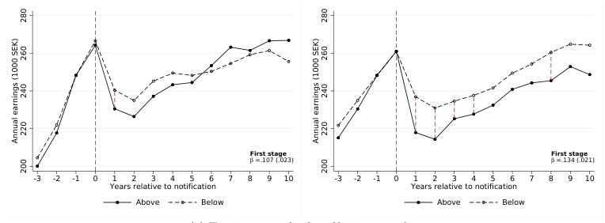

NOTE: figure/graphic rendered as an image from the PDF; its content is not machine-readable text. Caption (if any) follows as the next block.

**text found inside the figure**

**First stage** β =.107 (.023)

200 220 240 260 280 Annual earnings (1000 SEK)

-3 -2 -1 0 1 2 3 4 5 6 7 8 9 10 Years relative to notification

Above Below

**First stage** β =.134 (.021)

200 220 240 260 280 Annual earnings (1000 SEK)

-3 -2 -1 0 1 2 3 4 5 6 7 8 9 10 Years relative to notification

Above Below

(b) Large layoffs

(c) Earnings gap by layoff size quartile

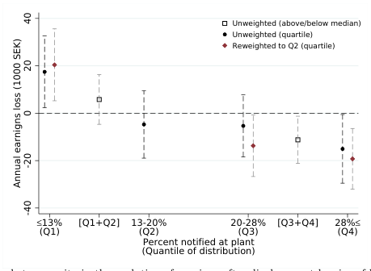

NOTE: figure/graphic rendered as an image from the PDF; its content is not machine-readable text. Caption (if any) follows as the next block.

**text found inside the figure**

-40 -20 0 20 40 Annual earnigns loss (1000 SEK)

≤13%

(Q1)

[Q1+Q2] 13-20% (Q2)

20-28% (Q3)

[Q3+Q4] 28%≤ (Q4) Percent notified at plant (Quantile of distribution)

Unweighted (above/below median)

Unweighted (quartile)

Reweighted to Q2 (quartile)

40

Page 46

Figure 11: Unemployment and non-employment by size of layoff

(a) Small layoffs: Long-term unemployment

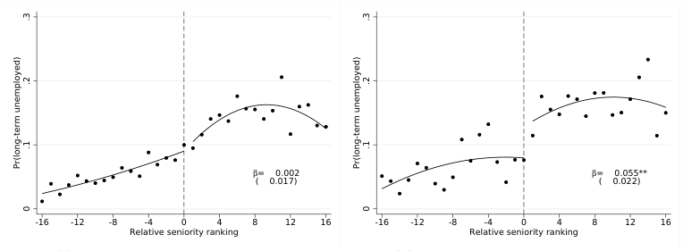

NOTE: figure/graphic rendered as an image from the PDF; its content is not machine-readable text. Caption (if any) follows as the next block.

**text found inside the figure**

β= 0.002

( 0.017)

0 .1 .2 .3 Pr(long-term unemployed)

-16 -12 -8 -4 0 4 8 12 16 Relative seniority ranking

β= 0.055**

( 0.022)

0 .1 .2 .3 Pr(long-term unemployed)

-16 -12 -8 -4 0 4 8 12 16 Relative seniority ranking

(b) Large layoffs: Long-term unemployment

(c) Small layoffs: Not in labor force

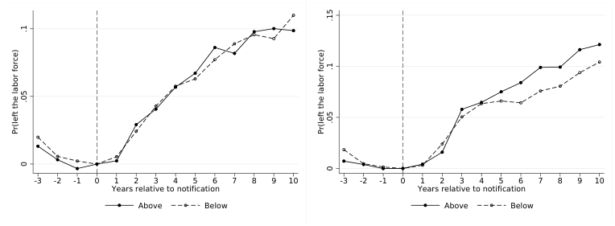

NOTE: figure/graphic rendered as an image from the PDF; its content is not machine-readable text. Caption (if any) follows as the next block.

**text found inside the figure**

0 .05 .1 Pr(left the labor force)

-3 -2 -1 0 1 2 3 4 5 6 7 8 9 10 Years relative to notification

Above Below

0 .05 .1 .15 Pr(left the labor force)

-3 -2 -1 0 1 2 3 4 5 6 7 8 9 10 Years relative to notification

Above Below

(d) Large layoffs: Not in labor force

Notes: Panel a) and b) show the probability of becoming long-term unemployed in the year after layoff for small and large layoffs, respectively. Panel c) and d) show the evolution of the probability of being not the labor force relative to time of notification for small and large layoffs, respectively. Not the labor force is defined as not working and while also not being registered at the PES. All regressions use a bandwidth of *±*16 and include a second order (top panel) or a first order (lower panel) polynomial function interacted with the threshold as well as order circuit fixed effects. Included in the regressions are controls for female, immigrant status, age, age squared level of education. Standard errors are clustered at the level of the order circuit.

41

Page 47

Figure 12: Earnings losses by size of layoff and size of industry relative to the local labor market

(a) Small layoff in small industry

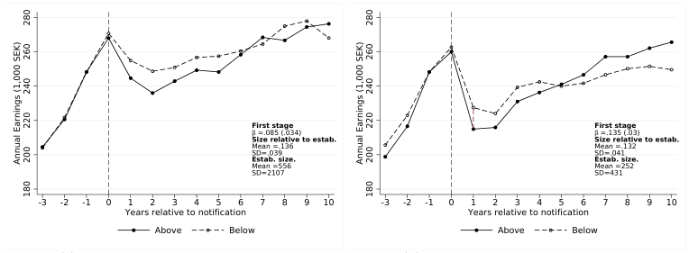

NOTE: figure/graphic rendered as an image from the PDF; its content is not machine-readable text. Caption (if any) follows as the next block.

**text found inside the figure**

**First stage** β =.085 (.034) **Size relative to estab.** Mean =.136 SD=.039 **Estab. size.** Mean =556 SD=2107

180 200 220 240 260 280 Annual Earnings (1,000 SEK)

-3 -2 -1 0 1 2 3 4 5 6 7 8 9 10 Years relative to notification

Above Below

**First stage** β =.135 (.03) **Size relative to estab.** Mean =.132 SD=.041 **Estab. size.** Mean =252 SD=431

180 200 220 240 260 280 Annual Earnings (1,000 SEK)

-3 -2 -1 0 1 2 3 4 5 6 7 8 9 10 Years relative to notification

Above Below

(b) Small layoff and large industry

(c) Large layoff and small industry

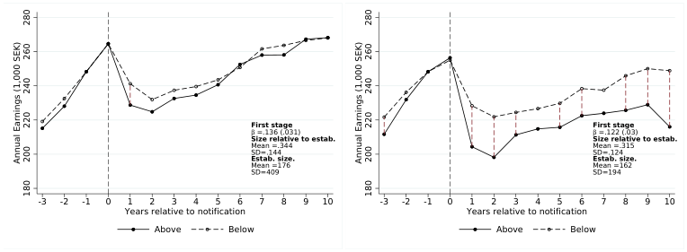

NOTE: figure/graphic rendered as an image from the PDF; its content is not machine-readable text. Caption (if any) follows as the next block.

**text found inside the figure**

**First stage** β =.136 (.031) **Size relative to estab.** Mean =.344 SD=.144 **Estab. size.** Mean =176 SD=409

180 200 220 240 260 280 Annual Earnings (1,000 SEK)

-3 -2 -1 0 1 2 3 4 5 6 7 8 9 10 Years relative to notification

Above Below

**First stage** β =.122 (.03) **Size relative to estab.** Mean =.315 SD=.124 **Estab. size.** Mean =162 SD=194

180 200 220 240 260 280 Annual Earnings (1,000 SEK)

-3 -2 -1 0 1 2 3 4 5 6 7 8 9 10 Years relative to notification

Above Below

(d) Large layoff and large industry

Notes: The figure shows annual earnings relative to the year of notification by size of layoff and size of the industry of the downsizing firm. The grouping of large and small are defined by the median in the sample for each category. For each time point, I plot the constant (hollow circles) and constant+*γ* (solid circles) estimate of equation (3) with annual earnings as the dependent variable which corresponds to the average predicted value of each outcome for workers to the left and right of the threshold, respectively. The dashed vertical line indicates significance at the 5-percent level where standard errors are clustered at the order circuit level. All regressions use a bandwidth of *±*16 and include a linear control function interacted with the threshold and baseline covariates: age, age squared, gender, immigrant status, educational attainment FE:s, earnings prior to notification as well as order circuit FE:s.

42

Page 48

Table 1: Sample characteristics

|  | All notified |  | LIFO |  | Mass layoff |
| --- | --- | --- | --- | --- | --- |
|  | workers |  | sample |  | sample |
|  | Mean | SD | Mean | SD | Mean SD |
| Age | 40 66 . | 12 74 . | 38 35 . | 12 06 . | 41 99 8 12 . . |
| Female | 0 35 . | 0 48 . | 0 19 . | 0 39 . | 0 35 0 48 . . |
| Immigrant | 0 17 . | 0 38 . | 0 16 . | 0 36 . | 0 14 0 35 . . |
| Tenure | 5 89 . | 5 70 . | 6 45 . | 5 83 . | 12 79 6 69 . . |
| Earningst−1 (1000 SEK) Level of education | 266 46 . | 137 50 . | 247 58 . | 95 13 . | 277 65 120 16 . . |
| Compulsary | 0 44 . | 0 50 . | 0 51 . | 0 50 . | 0 52 0 50 . . |
| Upper-secondary | 0 43 . | 0 50 . | 0 45 . | 0 50 . | 0 38 0 48 . . |
| College | 0 12 . | 0 33 . | 0 04 . | 0 20 . | 0 10 0 30 . . |
| Industry shares |  |  |  |  |  |
| Manufacturing | 0 33 . | 0 47 . | 0 83 . | 0 38 . | 0 61 0 49 . . |
| Construction | 0 08 . | 0 27 . | 0 14 . | 0 35 . | 0 01 0 11 . . |
| Transport | 0 11 . | 0 31 . | 0 00 . | 0 06 . | 0 09 0 29 . . |
| Non-financial services | 0 15 . | 0 36 . | 0 00 . | 0 00 . | 0 11 0 31 . . |
| Retail | 0 10 . | 0 30 . | 0 00 . | 0 00 . | 0 08 0 28 . . |
| Other | 0 22 . | 0 42 . | 0 03 . | 0 16 . | 0 08 0 28 . . |
| Firm size | 415 34 . | 1724 28 . | 472 98 . | 1407 74 . | 877 951 3261 11 . . |
| Establishment size | 98 63 . | 385 37 . | 169 38 . | 304 79 . | 158 45 163 95 . . |
| N | 425 939 , |  | 15 795 , |  | 30 112 , |

NOTE: table converted from PDF layout to HTML text; cell boundaries are reconstructed. See PDF if exact alignment matters.

Notes: The table shows summary statistics for workers notified of their displacement between 2005- 2015. The first column includes all workers notified in layoffs where more than 5 workers are involved and hence reported to the PES. The second column shows sample characteristics for workers used in the main analysis of this paper. The third column shows worker characteristics when following the standard restrictions imposed in the literature using mass layoffs (for details see section 5.1). All characteristics are computed at the individual level, expect firm and establishment size which reflects the average size per layoff.

43

Page 49

Table 2: Balancing of baseline covariates

|  | (1) | (2) | (3) | (4) | (5) |
| --- | --- | --- | --- | --- | --- |
| Earningst−1 | 0 0046 - . (0 0062) . | 0 0046 - . (0 0082) . | 0 0004 . (0 0049) . | 0 0041 - . (0 0102) . | 0 0030 . (0 0137) . |
| Female | 0 0060 - . (0 0051) . | 0 0062 - . (0 0069) . | 0 0002 - . (0 0039) . | 0 0092 - . (0 0115) . | 0 0003 - . (0 0149) . |
| Immigrant | 0 0034 . (0 0053) . | 0 0015 . (0 0067) . | 0 0008 . (0 0045) . | 0 0029 . (0 0104) . | 0049 - (0 0156) . |
| Age | 0 0001 . (0 0002) . | 0 0000 . (0 0003) . | 0 0001 . (0 0002) . | 0 0534 . (0 0368) . | 0 4268 . (0 5039) . |
| Compulsory school | ref . | ref . | ref . | 0 0025 . (0 0149) . | 0 0072 . (0 0228) . |
| Upper-Secondary school | 0 0002 - . (0 0047) . | 0 0010 - . (0 0051) . | 0 0001 . (0 0036) . | 0 0055 - . (0 0151) . | 0 0082 - . (0 0228) . |
| College | 0 0084 . (0 0108) . | 0 0059 . (0 0139) . | 0 0010 . (0 0089) . | 0 0029 . (0 0059) . | 0 0010 . (0 0084) . |
| Order of polynomial |  |  |  |  |  |
| 1st degree | ✓ | ✓ |  | ✓ |  |
| 2nd degree |  |  | ✓ |  | ✓ |
| Circuit FE |  | ✓ | ✓ | ✓ | ✓ |
| F -statistic | 0 397 . | 0 218 . | 0 126 . | · | · |
| p-value | 0 881 . | 0 971 . | 0 993 . | · | · |
| R2 | 0 736 . | 0 730 . | 0 880 . | · | · |
| # clusters | 564 | 564 | 564 | 564 | 564 |
| N | 15 795 , | 15 795 , | 15 795 , | 15 795 , | 15 795 , |

NOTE: table converted from PDF layout to HTML text; cell boundaries are reconstructed. See PDF if exact alignment matters.

Notes: The table show balance tests of baseline covariates at the LIFO threshold. Columns (1)-(3) show results from regressing the instrument (being above the threshold) on a set of baseline covariates and a polynomial control function in relative ranking interacted with the threshold. Annual earnings in measured in the year prior to notification and is normalized to reflect percentage point deviations from the mean of the workers below the threshold. The bottom of the table displays the *F*-statistic and the corresponding *p*-value from testing the hypothesis that all coefficients being jointly equal to zero. Columns (4)-(5) report results from balancing tests where each covariate has been regressed separately on the instrument and a polynomial control function in relative ranking interacted with the threshold. All regressions use a bandwidth *±*16. Standard errors clustered at the level of the order circuit and shown in parentheses.

44

Page 50

Table 3: First stage estimates

|  | (1) | (2) | (3) | (4) | (5) | (6) |
| --- | --- | --- | --- | --- | --- | --- |
| 1[RR > 0] | 0 120∗∗∗ . (0 015) . | 0 119∗∗∗ . (0 015) . | 0 092∗∗∗ . (0 017) . | 0 137∗∗∗ . (0 015) . | 0 068∗∗∗ . (0 019) . | 0 081∗∗∗ . (0 018) . |
| Polynomial order |  |  |  |  |  |  |
| 1st degree | ✓ | ✓ | ✓ | ✓ |  |  |
| 2nd degree |  |  |  |  | ✓ | ✓ |
| Covarites |  | ✓ | ✓ | ✓ | ✓ | ✓ |
| Circuit FE | ✓ | ✓ | ✓ | ✓ | ✓ | ✓ |
| Bandwidth ± | 16 | 16 | 11 | 20 | 18 | 22 |
| F -statistic | 61 08 . | 61 98 . | 30 40 . | 88 42 . | 12 20 . | 19 45 . |
| p-value | 0 000 . | 0 000 . | 0 000 . | 0 000 . | 0 001 . | 0 000 . |
| R2 | 0 381 . | 0 391 . | 0 376 . | 0 401 . | 0 395 . | 0 404 . |
| # clusters | 564 | 564 | 564 | 564 | 564 | 564 |
| N | 15 795 , | 15 795 , | 12 197 , | 17 954 , | 16 925 , | 18 894 , |

NOTE: table converted from PDF layout to HTML text; cell boundaries are reconstructed. See PDF if exact alignment matters.

Notes: The table shows the estimated first stage coefficient *γ* of equation (3) which is the difference in probability of displacement for worker just below and above the LIFO threshold. The bottom of the table displays the first stage *F*-statistic and its corresponding *p*-value used to evaluate instrument relevance. All regressions, expect column (4), use the optimal bandwidth selector suggested by Calonico et al. (2014) where column (1), (2) and (5) are based off the dependent variable annual earnings whereas column (3) and (6) use the probability of leaving the notifying firm. All regressions include order circuit FE:s and a control function interacted with the threshold where the polynomial order is indicated at the bottom of the table. Where indicated regressions control for the baseline covariates: age, age squared, gender, immigrant status, educational attainment FE:s. Standard errors clustered at the level of the order circuit and shown in parentheses. Asterisks indicate that the estimates are significantly different from zero at the *<sup>∗</sup>p <* 0*.*1, *<sup>∗∗</sup>p <* 0*.*05, *p <* 0*.*01 level.

45

Page 51

Table 4: IV-estimates on earnings and non-employment

Annual Earnings (1,000 SEK)

*Panel a) t* + 1 *t* + 2 *t* + 3 *t* + 4 *t* + 5 *t* + 6 *t* + 7 *t* + 8 *t* + 9 *t* + 10

Displaced -122.56*∗∗∗* -106.85*∗∗∗* -74.71*∗∗∗* -71.15*∗∗* -58.91*∗* -25.81 -3.63 -54.03 -25.47 -7.49

(26.00) (28.30) (28.82) (31.18) (32.56) (33.13) (35.20) (39.69) (44.88) (54.13)

Control mean 294 281 274 276 272 263 257 285 275 263 % of Control -41.73 -38.06 -27.28 -25.80 -21.64 -9.83 -1.41 -18.95 -9.25 -2.85

First stage *F*-statistic 62 62 62 60 56 57 48 41 37 26 *N* 15,795 15,795 15,795 15,604 14,987 14,313 12,612 11,442 11,007 7,674

Pr(Non-employment)

*Panel b) t* + 1 *t* + 2 *t* + 3 *t* + 4 *t* + 5 *t* + 6 *t* + 7 *t* + 8 *t* + 9 *t* + 10

Displaced 0.48*∗∗∗* 0.30*∗∗∗* 0.09 0.07 0.07 -0.06 -0.02 0.11 0.18*∗* 0.12 (0.09) (0.10) (0.09) (0.09) (0.10) (0.09) (0.10) (0.10) (0.11) (0.13)

Control mean 0.02 0.07 0.13 0.14 0.14 0.19 0.18 0.11 0.08 0.11 % of Control 1951.17 405.13 70.24 53.97 45.75 -30.16 -11.46 101.80 229.88 107.87 First stage *F*-statistic 62 62 62 60 56 57 48 41 37 26 *N* 15,795 15,795 15,795 15,604 14,987 14,313 12,612 11,442 11,007 7,674

Notes: The table shows IV estimates on annual earnings (top panel) and non-employment (bottom panel) by year relative to notification. Earnings

are in thousands of Swedish krona in 2005 values and employment is defined being registered as non-employed at least one month during a year.

Displacement has been instrumented with being just above the threshold. All regressions use a bandwidth of *±*16 and include a linear control function

interacted with the threshold and baseline covariates: age, age squared, gender, immigrant status, educational attainment FE:s as well as order circuit

FE:s. The bottom of the table show the first stage *F*-statistic. Standard errors clustered at the level of the order circuit and shown in parentheses.

Asterisks indicate that the estimates are significantly different from zero at the *∗p <* 0*.*1, *∗∗p <* 0*.*05, *p <* 0*.*01 level.

46

Page 52

Table 5: Cumulated average earnings losses after 6 years by margins of adjustment

|  |  |  | Adjustment margins |  |
| --- | --- | --- | --- | --- |
|  | A verage total | Months worked | log(Monthly wage) | Monthly hours |
|  | earnings loss (1) | (2) | (3) | worked (4) |
| Displaced | 76 84∗∗∗ - . (24 74) . | 1 21∗ - . (0 62) . | 0 04 - . (0 06) . | 3 59 - . (12 13) . |
| Control mean | 274 8 . | 11 1 . | 3 2 . | 134 3 . |
| % of Control | 0 28 - . | 0 11 - . | · | 0 03 - . |
| F -statistic | 57 | 57 | 32 | 32 |
| # clusters | 510 | 510 | 497 | 497 |
| N | 14 313 , | 14 313 , | 9 831 , | 9 821 , |

NOTE: table converted from PDF layout to HTML text; cell boundaries are reconstructed. See PDF if exact alignment matters.

47

Page 53

Table 6: Labor market outcomes by size of layoff

|  | Short-run (1 -3 years) | Medium-run (4 -6 years) | Long-run (7 -10 years) |
| --- | --- | --- | --- |
|  | Small Large (1) (2) | Small Large (3) (4) | Small Large (5) (6) |
| Earnings (1 ,000 SEK) | 84464∗∗ 76782∗∗ - . - . (33415) (35113) . . | 24195 38683 - . - . (42184) (36154) . . | 66757 69301∗ . - . (75548) (41882) . . |
|  | [0874] . | [0794] . | [0115] . |
| Non-employment (months) | 2344∗∗ 2402∗∗∗ . . (1013) (0899) . . | 0716 1871∗ . . (1211) (1001) . . | 0345 2493∗∗ - . . (1803) (1107) . . |
|  | [0966] . | [0462] . | [0180] . |
| Pr(unemployed) | 0396∗∗∗ 0566∗∗∗ . . (0118) (0124) . . | 0089 0139 - . . (0126) (0110) . . | 0273 0172∗∗ - . . (0179) (0080) . . |
|  | [0321] . | [0172] . | [0024] . |
| log(wage) | 0023 0002 . - . (0083) (0073) . . | 0052 0075 . . (0095) (0087) . . | 0119 0070 . . (0124) (0096) . . |
|  | [0816] . | [0857] . | [0756] . |
| Pr(changeindustry) | 0499∗∗∗ 0590∗∗∗ . . (0126) (0116) . . | 0601∗∗∗ 0405∗∗∗ . . (0192) (0131) . . | 0423∗∗ 0263∗ . . (0202) (0135) . . |
|  | [0593] . | [0400] . | [0511] . |
| Pr(changeoccupation) | 0436∗∗∗ 0481∗∗∗ . . (0148) (0101) . . | 0268 0297 . . (0351) (0237) . . |  |
|  | [0804] . | [0946] . |  |
| Pr(liveandworkinsameregion) | 0115 0156 . - . (0116) (0097) . . | 0262∗ 0217∗∗ . - . (0143) (0104) . . | 0217 0238∗∗ . - . (0205) (0118) . . |
|  | [0075] . | [0007] . | [0055] . |
| Pr(changeworkregion) | 0142 0153∗ . . (0107) (0085) . . | 0029 0263∗∗ . . (0155) (0108) . . | 0077 0277∗∗ . . (0209) (0118) . . |
|  | [0939] . | [0214] . | [0405] . |
| log(firmsize) | 0429 0183 - . . (0543) (0414) . . | 0183 0102 - . - . (0775) (0671) . . | 0276 0326 . . (1061) (0739) . . |
|  | [0370] . | [0937] . | [0969] . |

NOTE: table converted from PDF layout to HTML text; cell boundaries are reconstructed. See PDF if exact alignment matters.

Notes: The table shows IV-estimates on post employment outcomes, seperate for small and large layoffs by 3 time periods relative to layoff notification. Earnings are in thousands of Swedish krona in 2005 values. The probability of changing occupation can only be observred at maximum 6 years post notification due to occupational codes being recoded in 2012. All regressions use a bandwidth of *±*16 and include a linear control function interacted with the threshold and baseline covariates: age, age squared, gender, immigrant status, educational attainment FE:s as well as order circuit FE:s. Standard errors clustered at the level of the order circuit and shown in parentheses. Below each set of estimates in hard brackets are *p*-values from testing equality between the coefficents on small and large layoffs. Asterisks indicate that the estimates are significantly different from zero at the *<sup>∗</sup>p <* 0*.*1, *<sup>∗∗</sup>p <* 0*.*05, *<sup>∗∗∗</sup>p <* 0*.*01 level.

48

Page 54

### **A Additional figures and tables**

Figure A.1: Selection on observables

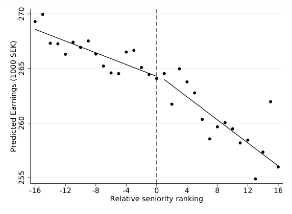

NOTE: figure/graphic rendered as an image from the PDF; its content is not machine-readable text. Caption (if any) follows as the next block.

**text found inside the figure**

255 260 265 270 Predicted Earnings (1000 SEK)

-16 -12 -8 -4 0 4 8 12 16 Relative seniority ranking

Notes: The figure shows predicted annual earnings as a function of a workers relative ranking within an order circuit (in discrete bins), normalized to zero at the threshold. The dependent variable is generated by taking the fitted values from a regression of annual earnings on age, age squared and dummies for gender, immigrant status, level of education FE’s and year FE’s. The regression comes from estimating equation (3) with a linear control function interacted with the threshold including order circuit FE:s, using a bandwidth of *±*16. The point estimate of the jump at the threshold is 0.064 with a standard error of 0.921. Standard errors are clustered at the order circuit level.

49

Page 55

Figure A.2: Frequency of observations around the threshold

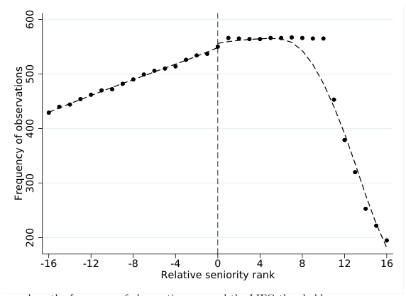

NOTE: figure/graphic rendered as an image from the PDF; its content is not machine-readable text. Caption (if any) follows as the next block.

**text found inside the figure**

200 300 400 500 600 Frequency of observations

-16 -12 -8 -4 0 4 8 12 16 Relative seniority rank

Notes: The figure show the frequency of observations around the LIFO threshold.

50

Page 56

Figure A.3: Probability of individual layoff notification

(a) Linear fit

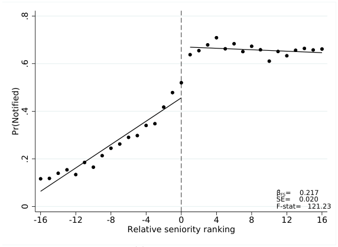

NOTE: figure/graphic rendered as an image from the PDF; its content is not machine-readable text. Caption (if any) follows as the next block.

**text found inside the figure**

0 .2 .4 .6 .8 Pr(Notified)

-16 -12 -8 -4 0 4 8 12 16 Relative seniority ranking

β̂FS= 0.217 SE= 0.020 F-stat= 121.23

(b) Quadratic fit

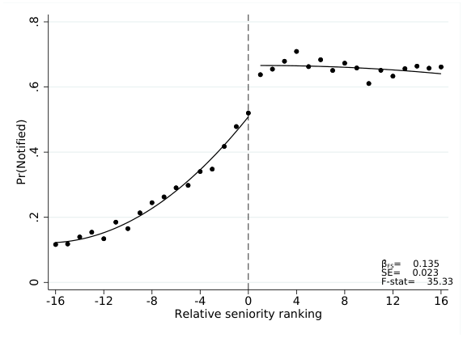

NOTE: figure/graphic rendered as an image from the PDF; its content is not machine-readable text. Caption (if any) follows as the next block.

**text found inside the figure**

0 .2 .4 .6 .8 Pr(Notified)

-16 -12 -8 -4 0 4 8 12 16 Relative seniority ranking

β̂FS= 0.135 SE= 0.023 F-stat= 35.33

Notes: The figures show the probability of receiving a layoff notification as a function of a workers relative ranking within an order circuit (in discrete bins), normalized to zero at the threshold. The regression include in a) a first order and b) second order polynomial function interacted with the threshold as well as order circuit fixed effects and is run using a bandwidth of *±*16. The point estimate of the jump at the threshold are supplied in the graph along with standard errors clustered at the order circuit level and *F*-statistic.

51

Page 57

Figure A.4: Balancing of individual covariates

(a) Linear fit

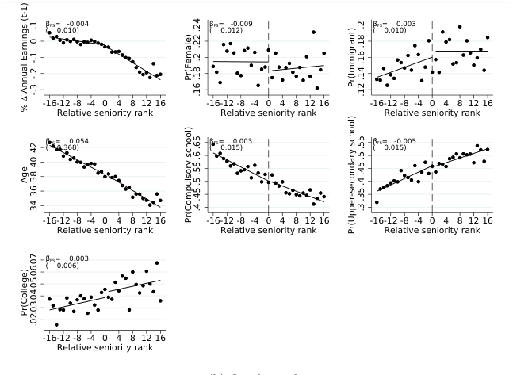

NOTE: figure/graphic rendered as an image from the PDF; its content is not machine-readable text. Caption (if any) follows as the next block.

**text found inside the figure**

-.3 -.2 -.1 0 .1 % ∆ Annual Earnings (t-1)

-16-12 -8 -4 0 4 8 12 16 Relative seniority rank

β̂FS= -0.004 ( 0.010)

.16 .18 .2 .22 .24 Pr(Female)

-16-12 -8 -4 0 4 8 12 16 Relative seniority rank

β̂FS= -0.009 ( 0.012)

.12 .14 .16 .18 .2 Pr(Immigrant)

-16-12 -8 -4 0 4 8 12 16 Relative seniority rank

β̂FS= 0.003 ( 0.010)

34 36 38 40 42 Age

-16-12 -8 -4 0 4 8 12 16 Relative seniority rank

β̂FS= 0.054 ( 0.368)

.4 .45 .5 .55 .6 .65 Pr(Compulsory school)

-16-12 -8 -4 0 4 8 12 16 Relative seniority rank

β̂FS= 0.003 ( 0.015)

.3 .35 .4 .45 .5 .55 Pr(Upper-secondary school)

-16-12 -8 -4 0 4 8 12 16 Relative seniority rank

β̂FS= -0.005 ( 0.015)

.02.03.04.05.06.07 Pr(College)

-16-12 -8 -4 0 4 8 12 16 Relative seniority rank

β̂FS= 0.003 ( 0.006)

(b) Quadratic fit

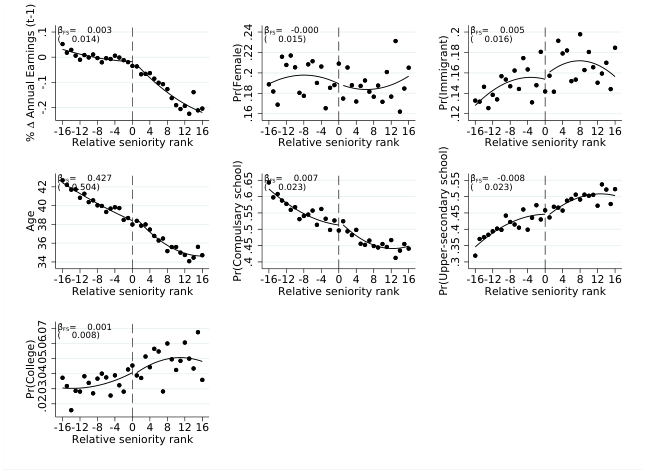

NOTE: figure/graphic rendered as an image from the PDF; its content is not machine-readable text. Caption (if any) follows as the next block.

**text found inside the figure**

-.2 -.1 0 .1 % ∆ Annual Earnings (t-1)

-16-12 -8 -4 0 4 8 12 16 Relative seniority rank

β̂FS= 0.003 ( 0.014)

.16 .18 .2 .22 .24 Pr(Female)

-16-12 -8 -4 0 4 8 12 16 Relative seniority rank

β̂FS= -0.000 ( 0.015)

.12 .14 .16 .18 .2 Pr(Immigrant)

-16-12 -8 -4 0 4 8 12 16 Relative seniority rank

β̂FS= 0.005 ( 0.016)

34 36 38 40 42 Age

-16-12 -8 -4 0 4 8 12 16 Relative seniority rank

β̂FS= 0.427 ( 0.504)

.4 .45 .5 .55 .6 .65 Pr(Compulsary school)

-16-12 -8 -4 0 4 8 12 16 Relative seniority rank

β̂FS= 0.007 ( 0.023)

.3 .35 .4 .45 .5 .55 Pr(Upper-secondary school)

-16-12 -8 -4 0 4 8 12 16 Relative seniority rank

β̂FS= -0.008 ( 0.023)

.02.03.04.05.06.07 Pr(College)

-16-12 -8 -4 0 4 8 12 16 Relative seniority rank

β̂FS= 0.001 ( 0.008)

Notes: The figures show balancing at the threshold of pre-determined worker characteristics using a a) first order and b) second order polynomial function interacted with the threshold as well as order circuit fixed effects and is run using a bandwidth of *±*16. The point estimate of the jump at the threshold are supplied in the graph along with standard errors clustered at the order circuit level.

52

Page 58

Figure A.5: Permutation test

(a) First stage

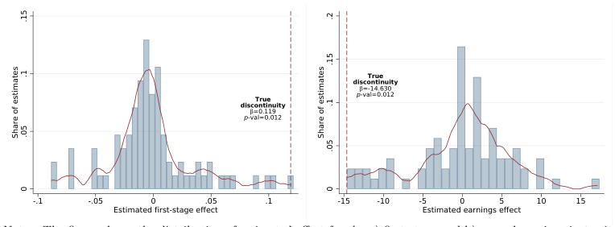

NOTE: figure/graphic rendered as an image from the PDF; its content is not machine-readable text. Caption (if any) follows as the next block.

**text found inside the figure**

**True discontinuity**

β=0.119 *p*-val=0.012

0 .05 .1 .15 Share of estimates

-.1 -.05 0 .05 .1 Estimated first-stage effect

**True discontinuity**

β=-14.630 *p*-val=0.012

0 .05 .1 .15 .2 Share of estimates

-15 -10 -5 0 5 10 15 Estimated earnings effect

(b) Annual earnings in *t* + 1

Notes: The figure shows the distribution of estimated effect for the a) first-stage and b) annual earnings in *t* + 1 for 85 different permutations of the RD-regression. For each permutation I vary the LIFO cut-off to values of the running variable between -56 and +28. Each regression, comes from estimating equation (3) with annual earnings as the dependent variable, using a bandwidth of *±*16 (around the placebo threshold) and includes a linear control function interacted with the threshold. The regressions also includes the baseline covariates: age, age squared, gender, immigrant status, educational attainment FE:s as well as order circuit FE:s. The true estimate is indicated by the vertical red dashed line and displayed in the figure along with the *p*-value showing the share of placebo estimates greater or equal to the true estimates (minimum possible *p*-value is 1/85=0.012). The solid red line is an Epanechnikov kernel showing the distribution among the estimates.

53

Page 59

Figure A.6: Probability of recall

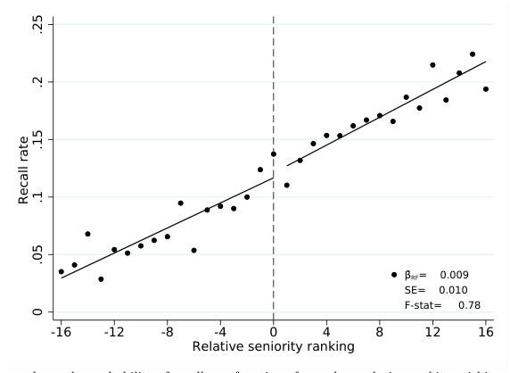

NOTE: figure/graphic rendered as an image from the PDF; its content is not machine-readable text. Caption (if any) follows as the next block.

**text found inside the figure**

0 .05 .1 .15 .2 .25 Recall rate

-16 -12 -8 -4 0 4 8 12 16 Relative seniority ranking

β̂RF= 0.009

SE= 0.010

F-stat= 0.78

Notes: The figure shows the probability of recall as a function of a workers relative ranking within an order circuit (in discrete bins), normalized to zero at the threshold. Recalled is defined as being registered as not working at the notifying firm for two consecutive months after layoff notification and after that coming back working at least three consecutive months at the firm. The regression include a first order polynomial function interacted with the threshold as well as order circuit fixed effects and is run using a bandwidth of *±*16. The point estimate of the jump at the threshold are supplied in the graph along with standard errors clustered at the order circuit level and *F*-statistic.

54

Page 60

Figure A.7: Evolution of annual earnings relative to year of notification for single layoff establishments

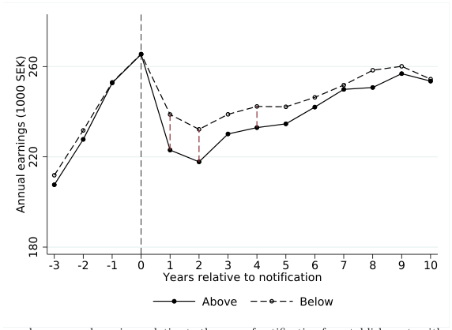

NOTE: figure/graphic rendered as an image from the PDF; its content is not machine-readable text. Caption (if any) follows as the next block.

**text found inside the figure**

180 220 260 Annual earnings (1000 SEK)

-3 -2 -1 0 1 2 3 4 5 6 7 8 9 10 Years relative to notification

Above Below

Notes: The figure shows annual earnings relative to the year of notification for establishments with only one layoff notification during the sample period. For each time point, I plot the constant (hollow circles) and constant+*γ* (solid circles) estimate of equation (3) with annual earnings as the dependent variable which corresponds to the average predicted value of each outcome for workers to the left and right of the threshold, respectively. The dashed vertical line indicates significance at the 5-percent level where standard errors are clustered at the order circuit level. The regressions use a bandwidth of *±*16 and include a linear polynomial function interacted with the threshold as well as order circuit fixed effects. Regressions control for the baseline covariates: age, age squared, gender, immigrant status, educational attainment FE:s.

55

Page 61

Figure A.8: Robustness of mass layoff earnings estimates

(a) Workers with *>* 3 years of tenure

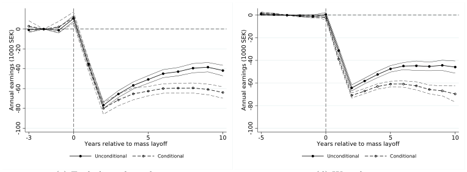

NOTE: figure/graphic rendered as an image from the PDF; its content is not machine-readable text. Caption (if any) follows as the next block.

**text found inside the figure**

-100 -80 -60 -40 -20 0 Annual earnings (1000 SEK)

-3 0 5 10 Years relative to mass layoff

Unconditional Conditional

-100 -80 -60 -40 -20 0 Annual earnings (1000 SEK)

-5 0 5 10 Years relative to mass layoff

Unconditional Conditional

(b) Including non-notified workers

(c) Excluding plant closures

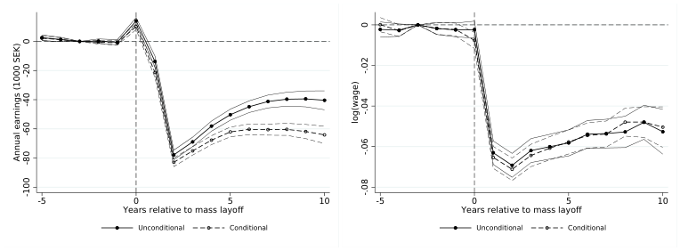

NOTE: figure/graphic rendered as an image from the PDF; its content is not machine-readable text. Caption (if any) follows as the next block.

**text found inside the figure**

-100 -80 -60 -40 -20 0 Annual earnings (1000 SEK)

-5 0 5 10 Years relative to mass layoff

Unconditional Conditional

-.08 -.06 -.04 -.02 0 log(wage)

-5 0 5 10 Years relative to mass layoff

Unconditional Conditional

(d) Wage losses

Notes: The figure shows the difference of annual earnings between displaced and non-displaced workers by years relative to a mass layoff event normalized to zero at *t −*3. Panel a) alter the tenure restriction and focuses on workers with at least 3 years of tenure. In panel b) displacement is defined as a worker leaving the plant in year *t* + 1 or *t* + 2 during a mass layoff event and thus include also non-notified workers. Panel c) exclude plant closures whereas panel d) plots the differences in wages between displaced and non-displaced workers. All plotted estimates are *δk* from equation (9) along with 95 percent confidence intervals where standard errors are clustered at the individual level. The solid black line show losses of displaced workers when not conditioning on the control group being employed in *t >* 0. The dashed black line conditions on the control group being employed throughout the entire sample period.

56

Page 62

Figure A.9: Earnings losses in using matched sample (reweighted)

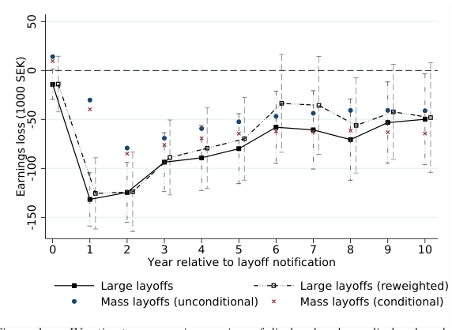

NOTE: figure/graphic rendered as an image from the PDF; its content is not machine-readable text. Caption (if any) follows as the next block.

**text found inside the figure**

-150 -100 -50 0 50 Earnings loss (1000 SEK)

0 1 2 3 4 5 6 7 8 9 10 Year relative to layoff notification

Large layoffs Large layoffs (reweighted) Mass layoffs (unconditional) Mass layoffs (conditional)

Notes: The Figure shows IV-estimates, comparing earnings of displaced and non-displaced workers just above and below the threshold, respectively. The black solid line shows the earnings gap using the matched control group replicating the estimates for large layoffs, replicating the estimates of Figure 9. The dashed line reweights the estimates for large layoffs to mimic the worker and industry composition of small layoffs as well as the time of notice. All regressions have a linear control function interacted with the threshold, using a bandwidth of *±*16 and include baseline covariates: age, age squared, gender, immigrant status, educational attainment FE:s as well as order circuit FE:s. Standard errors are clustered at the order circuit level. The blue (red) dots (cross) plots for comparison the unconditional (conditional) estimates from Figure 7 showing earnings losses using using the standard mass layoff approach (see section 5.1 for details on estimation).

57

Page 63

Figure A.10: Earnings losses by size of layoff

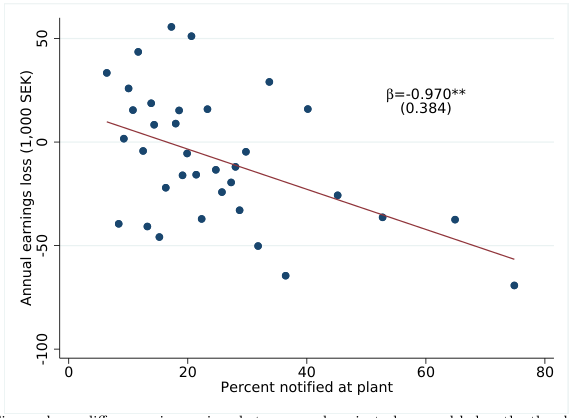

NOTE: figure/graphic rendered as an image from the PDF; its content is not machine-readable text. Caption (if any) follows as the next block.

**text found inside the figure**

β=-0.970**

(0.384)

-100 -50 0 50 Annual earnings loss (1,000 SEK)

0 20 40 60 80 Percent notified at plant

Notes: The Figure shows differences in earnings between workers just above and below the threshold within an order circuit, seven to ten years after notification. The Figure is a bin-scatter plot where separate estimates from each order circuit has been pooled into 35 equally sized bins and plotted against the size of the layoff. Each earnings differential estimate is estimated using a bandwidth of *±*16 and including a linear polynomial function interacted with the threshold as well as order circuit fixed effects. Included in the regressions are also controls for female, immigrant status, age, age squared level of education and earnings prior to notification. In estimate reported in the figure comes from a regression of the estimated earnings differential and size of layoff at the order circuit level using robust standard errors.

58

Page 64

Figure A.11: Leaving labor force by size of layoff for workers aged 18–55

(a) Small layoffs

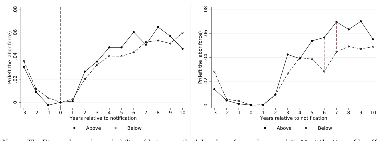

NOTE: figure/graphic rendered as an image from the PDF; its content is not machine-readable text. Caption (if any) follows as the next block.

**text found inside the figure**

0 .02 .04 .06 .08 Pr(left the labor force)

-3 -2 -1 0 1 2 3 4 5 6 7 8 9 10 Years relative to notification

Above Below

0 .02 .04 .06 .08 Pr(left the labor force)

-3 -2 -1 0 1 2 3 4 5 6 7 8 9 10 Years relative to notification

Above Below

(b) Large layoffs

Notes: The Figure shows the probability of being not the labor force for workers aged 18-55 at the time of layoff. This is done separately for a) small and b) large layoffs. Not the labor force is defined as not working and while also not being registered at the PES. All regressions use a bandwidth of *±*16 and include a second order (top panel) or a first order (lower panel) polynomial function interacted with the threshold as well as order circuit fixed effects. Included in the regressions are controls for female, immigrant status, age, age squared level of education. Standard errors are clustered at the level of the order circuit.

59

Page 65

Figure A.12: Correlation between size of layoff relative to establishment and local labor market

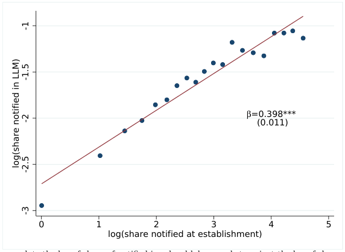

NOTE: figure/graphic rendered as an image from the PDF; its content is not machine-readable text. Caption (if any) follows as the next block.

**text found inside the figure**

β=0.398***

(0.011)

-3 -2.5 -2 -1.5 -1 log(share notified in LLM)

0 1 2 3 4 5 log(share notified at establishment)

Notes: The figure plots the log of share of notified in a local labor market against the log of share notified at the establishment in 20 equally sized bins. A local labor market is defined by municipality and 1-digit industry.

60

Page 66

Table A.1: Overview of studies of effects of job displacement on earnings

Data Sample restrictions Percent earnings

(main analysis) losses

Author(s) (year) Journal Country Time Tenure Gender Share Short-run Long-run

(state) (years) laid off (years) (years)

Jacobson et al. (1993) AER United States 1975– *≥*6 Both *≥*30% 40 25 (Pennsylvania) 1985 (1) (6)

Stevens (1997) JOLE United States 1968– None 89% *>* 0% 25 6-9 1988 male (1) (10+)

Eliason and Storrie (2006)*a*) JOLE Sweden 1983– None Both 100% 11.4 9.4 1999 (0) (12)

Sullivan and von Wachter (2009) QJE United States 1974– *≥*6 Males *≥*30% 40–50 15–20 (Pennsylvania) 1991 only (1) (9)

von Wachter et al. (2009) IZA WP United States 1974– *≥*6 Male *≥*30% 30 20 2004 focus (1) (15–20)

Couch and Placzek (2010) AER United States 2002– *≥*6 Both *≥*30% 32–33 12–15 (Connecticut) 2014 (1) (6)

Davis and von Wachter (2011) Brookings United States 1974– *≥*3 Males *≥*30% 25–39 15–20 papers 2008 only (1) (10-20)

Seim (2019) Labour Sweden 1999– *≥*1*.*5 Males *≥*80% 23.5 16.4 Economics 2009 only (1) (7)

Burdett et al. (2020) ReStad Germany 2002– *≥*3 Males *≥*30% 40 *∼*8

2014 only (0) (15)

Lachowska et al. (2020) AER United States 1981– *≥*6 Both *≥*30% 48 16 Washington 2005 (.25) (5)

Schmieder et al. (2023) Mimeo Germany 1980– *≥*3 Males *≥*30% 30 15 2008 only (0) (10)

Flaaen et al. (2019)*b*) AEJ Macro United States 2000– *≥*1 Both *≥*30% *· ·* 2006 (*·*) (*·*)

Fackler et al. (2021) JEEA Germany 2007– *≥*3 Both 100% 26 9 2009 (1) (5)

Athey et al. (2023) ArXiv Sweden 1997– *≥*3 Both *≥*90% 24 8 (WP) 2014 (1) (10)

Notes: The table summarizes results and sample restrictions made in some of the most cited studies using of earnings losses upon

job displacement. All papers listed above, expect Eliason and Storrie (2006) and Athey et al. (2023), include the additional sample

restrictions of establishments/firms having no less than 50 employees at the year of mass layoff.

*a*) The paper only reports nominal losses in Swedish krona so estimates are calculated based upon summary statistics provided in the

paper.

*b*) No exact point estimates are provided in the paper but merely graphical evidence. This due to confidentialty reasons according to

the authors.

61

Page 67

Table A.2: Characterizing compliers in LIFO sample

|  | Whole sample | Complier | Never-taker | Always-taker |
| --- | --- | --- | --- | --- |
| Earnings (1 000 SEK) , | 247 584 . (0 729) . | 246 317 . (2 337) . | 253 457 . (1 878) . | 241 945 . (1 803) . |
| Female | 0 191 . (0 003) . | 0 190 . (0 009) . | 0 172 . (0 007) . | 0 213 . (0 008) . |
| Immigrant | 0 158 . (0 003) . | 0 156 . (0 009) . | 0 154 . (0 007) . | 0 164 . (0 007) . |
| Age ( years) | 38 347 . (0 098) . | 38 772 . (0 293) . | 38 175 . (0 231) . | 38 102 . (0 254) . |
| Compulsory school | 0 511 . (0 004) . | 0 543 . (0 012) . | 0 482 . (0 010) . | 0 513 . (0 010) . |
| Upper secondary school | 0 448 . (0 004) . | 0 430 . (0 013) . | 0 462 . (0 010) . | 0 452 . (0 010) . |
| College | 0 040 . (0 001) . | 0 027 . (0 005) . | 0 056 . (0 004) . | 0 035 . (0 003) . |

NOTE: table converted from PDF layout to HTML text; cell boundaries are reconstructed. See PDF if exact alignment matters.

Notes: The table shows summary statistics by complier status following Abadie et al. (2002) and using the user-written package ivdesc in Stata. Bootstraped standrad errors shown in parentheses and based on 1000 replications.

62

Page 68

Table A.3: Characteristics of displaced vs. nondisplaced workers in mass layoff sample

|  | (1) | (2) | (3) |
| --- | --- | --- | --- |
|  | Displaced | Non-displaced | Difference |
|  | workers | workers | col (1) -(2) . |
| Worker characteristics |  |  |  |
| Age | 42 47 . | 42 48 . | 0 02 - . |
| Tenure | 10 94 . | 11 10 . | 0 16 - . |
| Primary school | 0 57 . | 0 59 . | 0 02 - . |
| High school | 0 35 . | 0 34 . | 0 01 . |
| College | 0 08 . | 0 07 . | 0 00 . |
| Earnings (t -1) | 305 46 . | 296 59 . | 8 86 . |
| Earnings (t -2) | 297 36 . | 293 10 . | 4 26 . |
| Earnings (t -3) | 291 72 . | 288 05 . | 3 67 . |
| Industry shares |  |  |  |
| Agricultural | 0 00 . | 0 00 . | 0 00 . |
| Mining | 0 00 . | 0 00 . | 0 00 . |
| Manufacturing | 0 61 . | 0 61 . | 0 00 . |
| Construction | 0 06 . | 0 06 . | 0 00 - . |
| Retail | 0 10 . | 0 10 . | 0 00 - . |
| Transport | 0 09 . | 0 10 . | 0 01 - . |
| Financial | 0 00 . | 0 00 . | 0 00 . |
| Non-financial | 0 06 . | 0 06 . | 0 00 - . |
| N | 11 440 , | 11 440 , | 22 880 , |

NOTE: table converted from PDF layout to HTML text; cell boundaries are reconstructed. See PDF if exact alignment matters.

63

Page 69

Table A.4: Sample characteristics by size of layoff

|  | LIFO |  | Mass layoff |  | Mass layoff |
| --- | --- | --- | --- | --- | --- |
|  | sample |  | sample |  | sample ( reweighted) |
|  | Mean | SD | Mean | SD | Mean SD |
| Age | 38 35 . | 12 06 . | 42 04 . | 8 09 . | 40 57 10 10 . . |
| Female | 0 19 . | 0 39 . | 0 35 . | 0 48 . | 0 24 0 43 . . |
| Tenure | 6 00 . | 5 83 . | 12 80 . | 6 70 . | 8 84 5 40 . . |
| Immigrant | 0 16 . | 0 36 . | 0 15 . | 0 35 . | 0 17 0 38 . . |
| Level of education |  |  |  |  |  |
| Compulsary school | 0 51 . | 0 50 . | 0 52 . | 0 50 . | 0 58 0 49 . . |
| Upper-secondary school | 0 45 . | 0 50 . | 0 38 . | 0 48 . | 0 39 0 49 . . |
| College | 0 04 . | 0 20 . | 0 10 . | 0 30 . | 0 04 0 19 . . |
| log( establishment size) | 4 84 . | 0 94 . | 4 96 . | 0 71 . | 4 88 0 72 . . |
| Notification year | 2009 23 . | 2 20 . | 2010 02 . | 2 97 . | 2009 49 2 34 . . |
| Industry shares |  |  |  |  |  |
| Manufacturing | 0 83 . | 0 38 . | 0 61 . | 0 49 . | 0 87 0 34 . . |
| Construction | 0 14 . | 0 35 . | 0 01 . | 0 12 . | 0 09 0 28 . . |
| Transport | 0 00 . | 0 06 . | 0 09 . | 0 29 . | 0 01 0 08 . . |
| Non-financial services | 0 00 . | 0 00 . | 0 11 . | 0 32 . | 0 00 0 00 . . |
| Retail | 0 00 . | 0 00 . | 0 08 . | 0 28 . | 0 00 0 00 . . |
| Other | 0 03 . | 0 16 . | 0 08 . | 0 28 . | 0 04 0 19 . . |
| N | 15 795 , |  | 30 112 , |  | 24 145 , |

NOTE: table converted from PDF layout to HTML text; cell boundaries are reconstructed. See PDF if exact alignment matters.

Notes: The table shows average charateristics and standrad deviations of the LIFO sample (column 1) used for analysis in section 4 an the mass layoff sample used in section 5.1. Column 3 show the sample in column 2 reweighted to mimic the sample composition of column (1).

64

Page 70

Table A.5: Sample characteristics by size of layoff

|  |  | Size of layoff as share of workforce |  |  |  |  |
| --- | --- | --- | --- | --- | --- | --- |
|  |  |  | ( quantile of |  | distribtuion) |  |
| Panel A Unweighted sample . | ≤ 13% (Q1) |  | 13 19% − (Q2) |  | 19 28% − (Q3) | 28% ≤ (Q4) |
|  | Mean | SD | Mean | SD | Mean SD | Mean SD |
| Age | 36 39 . | 11 83 . | 36 46 . | 11 92 . | 39 04 11 91 . . | 41 64 11 78 . . |
| Female | 0 24 . | 0 43 . | 0 22 . | 0 41 . | 0 18 0 38 . . | 0 13 0 34 . . |
| Tenure ( months) | 61 78 . | 60 24 . | 66 02 . | 62 20 . | 83 13 68 27 . . | 99 85 81 50 . . |
| Immigrant | 0 18 . | 0 38 . | 0 18 . | 0 38 . | 0 16 0 36 . . | 0 11 0 32 . . |
| Level of education |  |  |  |  |  |  |
| Compulsary | 0 44 . | 0 50 . | 0 47 . | 0 50 . | 0 55 0 50 . . | 0 60 0 49 . . |
| Upper-secondary | 0 50 . | 0 50 . | 0 49 . | 0 50 . | 0 42 0 49 . . | 0 37 0 48 . . |
| College | 0 06 . | 0 23 . | 0 04 . | 0 20 . | 0 03 0 17 . . | 0 03 0 18 . . |
| Industry shares |  |  |  |  |  |  |
| Manufacturing | 0 88 . | 0 33 . | 0 86 . | 0 34 . | 0 82 0 39 . . | 0 77 0 42 . . |
| Construction | 0 11 . | 0 31 . | 0 12 . | 0 33 . | 0 15 0 36 . . | 0 17 0 38 . . |
| Transport | 0 01 . | 0 09 . | 0 00 . | 0 00 . | 0 00 0 00 . . | 0 01 0 08 . . |
| Non-financial services | 0 00 . | 0 00 . | 0 00 . | 0 00 . | 0 00 0 00 . . | 0 00 0 00 . . |
| Retail | 0 00 . | 0 00 . | 0 00 . | 0 00 . | 0 00 0 00 . . | 0 00 0 00 . . |
| Other | 0 01 . | 0 09 . | 0 02 . | 0 12 . | 0 03 0 17 . . | 0 05 0 22 . . |
| N | 3 951 , |  | 3 919 , |  | 3 917 , | 3 924 , |

NOTE: table converted from PDF layout to HTML text; cell boundaries are reconstructed. See PDF if exact alignment matters.

Size of layoff as share of workforce

(quantile of distribtuion)

| Panel B Reweighted sample . | ≤ 13% (Q1) |  | 13 19% − (Q2) |  | 19 28% − (Q3) |  | 28% ≤ (Q4) |
| --- | --- | --- | --- | --- | --- | --- | --- |
|  | Mean | SD | Mean | SD | Mean | SD | Mean SD |
| Age | 36 13 . | 11 84 . | 36 46 . | 11 92 . | 36 06 . | 11 56 . | 36 49 11 19 . . |
| Female | 0 19 . | 0 39 . | 0 22 . | 0 41 . | 0 23 . | 0 42 . | 0 21 0 41 . . |
| Tenure ( months) | 66 51 . | 64 78 . | 66 02 . | 62 20 . | 65 27 . | 55 62 . | 63 55 59 39 . . |
| Immigrant | 0 17 . | 0 38 . | 0 18 . | 0 38 . | 0 17 . | 0 37 . | 0 17 0 38 . . |
| Level of education |  |  |  |  |  |  |  |
| Compulsary | 0 47 . | 0 50 . | 0 47 . | 0 50 . | 0 47 . | 0 50 . | 0 46 0 50 . . |
| Upper-secondary | 0 50 . | 0 50 . | 0 49 . | 0 50 . | 0 49 . | 0 50 . | 0 49 0 50 . . |
| College | 0 03 . | 0 18 . | 0 04 . | 0 20 . | 0 04 . | 0 19 . | 0 04 0 21 . . |
| Industry shares |  |  |  |  |  |  |  |
| Manufacturing | 0 88 . | 0 32 . | 0 86 . | 0 34 . | 0 85 . | 0 35 . | 0 86 0 34 . . |
| Construction | 0 11 . | 0 31 . | 0 12 . | 0 33 . | 0 12 . | 0 33 . | 0 13 0 34 . . |
| Transport | 0 00 . | 0 00 . | 0 00 . | 0 00 . | 0 00 . | 0 00 . | 0 00 0 00 . . |
| Non-financial services | 0 00 . | 0 00 . | 0 00 . | 0 00 . | 0 00 . | 0 00 . | 0 00 0 00 . . |
| Retail | 0 00 . | 0 00 . | 0 00 . | 0 00 . | 0 00 . | 0 00 . | 0 00 0 00 . . |
| Other | 0 01 . | 0 09 . | 0 02 . | 0 12 . | 0 03 . | 0 16 . | 0 01 0 08 . . |
| N | 3 523 , |  | 3 919 , |  | 3 584 , |  | 3 446 , |

NOTE: table converted from PDF layout to HTML text; cell boundaries are reconstructed. See PDF if exact alignment matters.

Notes: The table shows summary statistics seperatly for each quartile of layoff size relative to the establishment. Panel A) presents unweighted estimates whereas Panel B) weights Q1, Q3 and Q4 to mimic the sample composition of Q2.

65

Page 71

Table A.6: Balancing of covariates between orginal and matched sample

|  | (1) | (2) | (3) |
| --- | --- | --- | --- |
| Earnings in t −1 (1000 SEK) | 0 0523 . (0 0394) . | 0 0840∗ . (0 0488) . | 0 0778 . (0 1199) . |
| Female | 0 0075 - . (0 0149) . | 0 0119 - . (0 0183) . | 0 0228 - . (0 0348) . |
| Immigrant | 0 0016 . (0 0172) . | 0 0046 - . (0 0195) . | 0 0009 . (0 0368) . |
| Age | 0 0000 - . (0 0003) . | 0 0002 . (0 0004) . | 0 0000 - . (0 0011) . |
| Primary School | ref . | ref . | ref . |
| High school | 0 0017 - . (0 0081) . | 0 0002 - . (0 0091) . | 0 0022 - . (0 0218) . |
| College | 0 0342∗∗ - . (0 0170) . | 0 0271 - . (0 0225) . | 0 0365 - . (0 0570) . |
| Circuit FE |  | ✓ |  |
| Circuit×RR FE |  |  | ✓ |
| F -statistic | 0 905 . | 0 880 . | 0 216 . |
| p-value | 0 491 . | 0 509 . | 0 972 . |
| # clusters | 513 | 513 | 513 |
| N | 15 072 , | 15 072 , | 14 168 , |

NOTE: table converted from PDF layout to HTML text; cell boundaries are reconstructed. See PDF if exact alignment matters.

Notes: The table show balancing of pre determined covariets between workers below the threshold and matched workers using propensity score matching. Columns (1)-(3) show results from regressing the instrument (being above the threshold) on a set of baseline covariates and a polynomial control function in relative ranking interacted with the threshold. Annual earnings in measured in the year prior to notification in 1000 SEK. The bottom of the table displays the *F*-statistic and the corresponding *p*-value from testing the hypothesis that all coefficients being jointly equal to zero. All regressions use a bandwidth *±*16. Standard errors clustered at the level of the order circuit and shown in parentheses. Asterisks indicate that the estimates are significantly different from zero at the *<sup>∗</sup>p <* 0*.*1, *<sup>∗∗</sup>p <* 0*.*05, *<sup>∗∗∗</sup>p <* 0*.*01 level.

66

Page 72

Table A.7: Balancing of covariates at threshold with matched workers

|  | (1) | (2) | (3) | (4) | (5) |
| --- | --- | --- | --- | --- | --- |
| Earnings in t −1 (1000 SEK) | 0 0134 - . (0 0235) . | 0 0113 - . (0 0281) . | 0 0064 - . (0 0163) . | 0 0024 - . (0 0034) . | 0 0022 - . (0 0045) . |
| Female | 0 0030 - . (0 0060) . | 0 0018 - . (0 0070) . | 0 0018 - . (0 0041) . | 0 0032 - . (0 0136) . | 0 0068 - . (0 0179) . |
| Immigrant | 0 0064 . (0 0068) . | 0 0073 . (0 0074) . | 0 0027 - . (0 0047) . | 0 0113 . (0 0131) . | 0 0072 - . (0 0186) . |
| Age | 0 0003 - . (0 0002) . | 0 0004 - . (0 0003) . | 0 0001 - . (0 0002) . | 0 7525∗ - . (0 4181) . | 0 4330 - . (0 5583) . |
| Primary school | ref . | ref . | ref . | 0 0150 - . (0 0180) . | 0 0068 . (0 0248) . |
| High school | 0 0014 . (0 0056) . | 0 0000 - . (0 0061) . | 0 0029 - . (0 0039) . | 0 0114 . (0 0182) . | 0 0132 - . (0 0248) . |
| College | 0 0143 . (0 0119) . | 0 0055 . (0 0151) . | 0 0050 . (0 0100) . | 0 0036 . (0 0060) . | 0 0064 . (0 0089) . |
| Order of polynomial |  |  |  |  |  |
| 1st degree | ✓ | ✓ |  | ✓ |  |
| 2nd degree |  |  | ✓ |  | ✓ |
| Circuit FE |  | ✓ | ✓ | ✓ | ✓ |
| F -statistic | 0 984 . | 0 686 . | 0 379 . | · | · |
| p-value | 0 435 . | 0 661 . | 0 892 . | · | · |
| R2 | 0 737 . | 0 731 . | 0 880 . | · | · |
| # clusters | 513 | 513 | 513 | 513 | 513 |
| N | 13 818 , | 13 818 , | 13 818 , | 13 848 13 887 , – , |  |

NOTE: table converted from PDF layout to HTML text; cell boundaries are reconstructed. See PDF if exact alignment matters.

Notes: The table show balance tests of baseline covariates at the LIFO threshold between the original sample (above threshold) and the matched sample (below threshold) which consists of workers matched to original workers below the threshold. Columns (1)-(3) show results from regressing the instrument (being above the threshold) on a set of baseline covariates and a polynomial control function in relative ranking interacted with the threshold. Annual earnings in measured in the year prior to notification in 1000 SEK. The bottom of the table displays the *F*-statistic and the corresponding *p*-value from testing the hypothesis that all coefficients being jointly equal to zero. Columns (4)-(5) report results from balancing tests where each covariate has been regressed separately on the instrument and a polynomial control function in relative ranking interacted with the threshold. All regressions use a bandwidth *±*16. Standard errors clustered at the level of the order circuit and shown in parentheses. Asterisks indicate that the estimates are significantly different from zero at the *<sup>∗</sup>p <* 0*.*1, *<sup>∗∗</sup>p <* 0*.*05, *∗∗∗p <* 0*.*01 level.

67

Page 73

### **B Optimal bandwidth**

Figure B.1 reproduces Figure 5 using the optimal bandwidth selector suggested by Calonico

et al. (2014) with and without adjusting for pre-determined covariates in the bottom and top

panel, respectively.

Figure B.1: Evolution of annual earnings relative to year of notification (optimal bandwidth)

(a) Linear fit without covariates

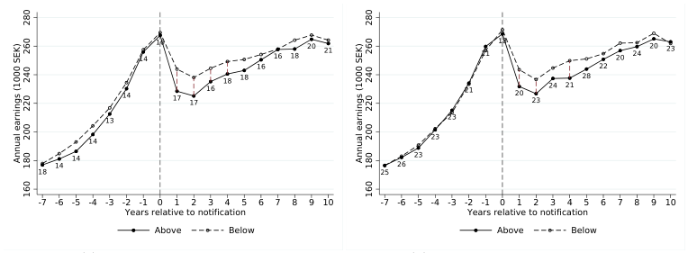

NOTE: figure/graphic rendered as an image from the PDF; its content is not machine-readable text. Caption (if any) follows as the next block.

**text found inside the figure**

18 14 14

14

13

14

14

16

17 17

16 18 18

16

16 18 20 21

160 180 200 220 240 260 280 Annual earnings (1000 SEK)

-7 -6 -5 -4 -3 -2 -1 0 1 2 3 4 5 6 7 8 9 10 Years relative to notification

Above Below

25 26 23

23

23

21

21

18

20 23

24 21 28 22 20 24 20 23

160 180 200 220 240 260 280 Annual earnings (1000 SEK)

-7 -6 -5 -4 -3 -2 -1 0 1 2 3 4 5 6 7 8 9 10 Years relative to notification

Above Below

(b) Quadratic fit without covariates

(c) Linear fit with covariates

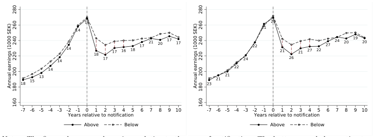

NOTE: figure/graphic rendered as an image from the PDF; its content is not machine-readable text. Caption (if any) follows as the next block.

**text found inside the figure**

18 15 13

14

14

14

14

16

18 17

17 16 18 17 21 20 17 17

160 180 200 220 240 260 280 Annual earnings (1000 SEK)

-7 -6 -5 -4 -3 -2 -1 0 1 2 3 4 5 6 7 8 9 10 Years relative to notification

Above Below

23 21 21

22

24

22

21

20

21

26

21 27 22 27 24 20 19 20

160 180 200 220 240 260 280 Annual earnings (1000 SEK)

-7 -6 -5 -4 -3 -2 -1 0 1 2 3 4 5 6 7 8 9 10 Years relative to notification

Above Below

(d) Quadratic fit with covariates

Notes: The figure show annual earnings relative to the year of notification. The bottom panel show estimates while controlling for female, immigrant status, age, age squared and level of education FE:s, whereas the top panel excludes these covariates. For each time point, I plot the constant (hollow circles) and constant+*γ* (solid circles) estimate of equation (3) which corresponds to the average predicted value of each outcome for workers to the left and right of the threshold, respectively. Indicated below each point is the optimal bandwidth suggested by Calonico et al. (2014). The dashed vertical line indicates significance at the 5-percent level where standard errors are clustered at the order circuit level. The regressions include a linear or second order polynomial function interacted with the threshold as well as order circuit fixed effects.

68

Page 74

### **C Notifications - institutions, law and data**

Mandated notice policies are far from a unique Swedish phenomenon, but, exists in all OECD

countries. Swedish labor law stipulates that an employer who wants to lay off a worker must

give written notice to him or her in advance. The length of the notification period in Sweden is

a step-wise function determined by a workers’ tenure (at the time of notice) where the minimum

and so on until the maximum legislated notice of 6 month is acquired at 10 years of tenure. The

law functions as a minimum requirement and can be side-stepped by collective agreements that

are in favor of the worker. For instance, many white-collar agreements stipulate that workers

above age 55 with 10 years of tenure get an additional 6 months of notice. Workers and firms

are also free to agree on severance packages that deviate from the default rules as long as they

are perceived as more generous from the worker’s point of view.

A firm intending to notify at least 5 workers must report this to the Public Employment

Services (PES). In a first stage, the employer reports to the PES how many workers it intends

to displace. How early the firm needs notify the PES is regulated in law and depends on

the number of intended displacements with: 5–25 workers requiring 2 months before the first

displacement, 26–100 workers requiring 4 months and more than 100 workers requiring 6 months

before the first worker is laid off. If a firm fails to oblige by the law, it is subject to a fine of

100–500 Swedish krona per worker and week the notification is late. Note that, while these rules

require firms to report earlier to the PES, this does not necessarily imply that workers get their

individual notice earlier. Whether the workers are made aware of the notification being sent in

to the PES is up to the employer. The PES treats all information received by the employer as

confidential.

Upon the initial report to the PES, the firm enter negotiations with the labor unions on who

to lay off, respecting the last-in-fist-out principle. In a second stage, a list of all individuals who

are notified of their displacement is later sent in to the PES. The list contains the workers’ name,

social security and date of their last day of employment and individual notification. Employers

are free to recall entire notification or update the list, subtracting or adding workers, as long as

the number of notified workers on the list does not exceed the number of intended displacements

stated in the first stage.

In less than one percent of all instances, the entire notification is recalled by the employer.

In notifications that lead to at least one worker being displaced, about 15 percent of notified

workers are still working at the notifying firm 2 years after notification. Adding workers at

69

Page 75

a later point in time to the list in uncommon. Most likely due to negotiations with he union

having already been settled when the original list is sent in. Only about 1.2 percent of all

notifications have workers added to or taken off the list after the initial submission.

No systematic review of to what extent firms comply with the above mentioned time restric-

tions imposed by the notification law have not been done. However, in email correspondence

with the PES, they reveal that their impression is that a great majority of all displacements

exceeding 5 workers are reported to them. When it comes the larger layoffs, probably all. With

respect to individual notification times, essentially all employers comply with the law and/or

the collective agreement regulating the minimum amount of notice. This as there are almost

always labor unions present to supervise the process.

70

Page 76

### **D Calculation of tenure**

A worker’s relative seniority is directly related to tenure since it is defined as his tenure relative

to the tenure distribution of the rest of the workforce within an order circuit. Hence, any

measurement error in workers’ individual tenure or the full tenure distribution within the circuit

induces measurement error in the running variable as defined in equation (1).

I construct tenure using the indicators of first and last month worked at a firm which are

reported by the employer along with the annual income statement in the matched employer-

employee data. Employment spells may be interrupted by months of non-employment if the

employer has reported two or more spells of employment where e.g. the first spell may last

January to March and the second spell e.g. August to December. As such I can create monthly

markers indicating whether the worker is employed in any given month at a particular firm or an

establishment. Using these monthly indicators I rank workers, who are employed at the time of

notification, by their date of first employment at the firm. As noted in Section 2.1 there may be

false ties in tenure due to employers too often reporting January as the month where the worker

started employment. To avoid such ties which are due to measurement error, I divide workers

with the same start date into quartiles of annual earnings in the first year of employment, where

workers in lower quartile are assumed to have started employment later than workers in higher

quartiles. I drop entire circuits where more than 2/3 of workers have a tenure equal to the

mode of the circuit as these ties are most likely due to so called false firm deaths where firms

for other reason than bankruptcy change identification number. Finally, when constructing the

running variable, relative ranking, I break ties in tenure by age at notification (following the

LIFO rule).

Even if tenure was perfectly measured, there are still potential sources of measurement

error in the running variable. The LIFO rule which applies at the CBA *×* establishment level

is proxied by 2-digit occupational codes. The lack of a one-to-one mapping between CBA’s

and occupation codes makes it difficult to precisely define the relevant workforce subject to

the notification. Thus the full tenure distribution within the order circuit may be obscured by

including workers in an order circuit which they do not belong to. Misallocating just one worker

will render the circuit too large or too small and thereby leading me to place the discontinuity

in the wrong place in the tenure distribution when normalizing the running variable with the

number of notified workers (*Nc*). To minimize the risk of missmeasuring order circuits I restrict

the circuits to be no larger than 100 workers.

Importantly, as long as there is some information about the true running variable in the

proxy that is used, the above listed causes which may generate measurement error does not

71

Page 77

affect the consistency or causal interpretation of my estimates but only induces noise in the

running variable (*RR*), thereby attenuating the first stage. However, had there been zero mass

of individuals with the correct values of their running variable, the RD-estimator would have

been inconsistent as any first stage discontinuity would have been smoothed out (see Davezies

and Le Barbanchon, 2017). By analogy, this is similar to what happens in two-stage least

squares with weak instruments where the denominator in the Wald-estimator is zero.

72

Page 78

#### **Appendix References**

**Calonico, Sebastian, Matias D. Cattaneo, and Rocio Titiunik**, “Robust Nonparametric

Confidence Intervals for Regression-Discontinuity Designs,” *Econometrica*, 2014, 82 (6), 2295–

2326

**Davezies, Laurent and Thomas Le Barbanchon**, “Regression discontinuity design with

continuous measurement error in the running variable,” *Journal of Econometrics*, 2017, 200 (2),

260–281. Measurement Error Models.

73